# Project2

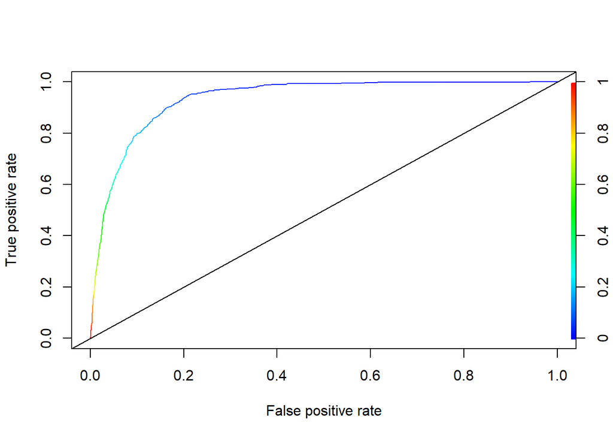

```r
#Acc 91.5%, Sens. 45%, Spec. 97%

#ROCR
results.lasso <-
  prediction(fit.pred.lasso, test$y, label.ordering = c("no", "yes"))
roc.lasso = performance(results.lasso, measure = "tpr", x.measure = "fpr")
plot(roc.lasso, colorize = TRUE)
abline(a = 0, b = 1)
```

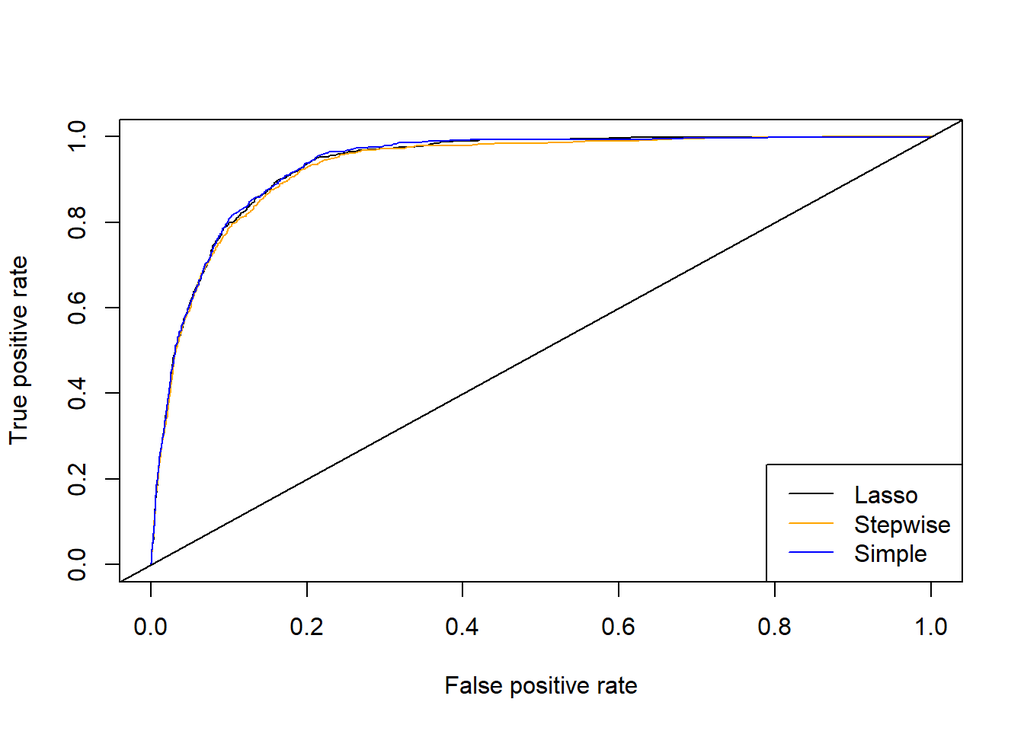

```r
#step model prediction
results.step <-
  prediction(fit.pred.step, test$y, label.ordering = c("no", "yes"))
roc.step = performance(results.step, measure = "tpr", x.measure = "fpr")

simple.log <- glm(y ~ ., family = "binomial", data = train)
fit.pred.origin <- predict(simple.log, newdata = test, type = "response")
results.origin <-
  prediction(fit.pred.origin, test$y, label.ordering = c("no", "yes"))
roc.origin = performance(results.origin, measure = "tpr", x.measure = "fpr")

#plot ROC curves
plot(roc.lasso)
plot(roc.step, col = "orange", add = TRUE)
plot(roc.origin, col = "blue", add = TRUE)
legend(
  "bottomright",
  legend = c("Lasso", "Stepwise", "Simple"),
  col = c("black", "orange", "blue"),
  lty = 1,
  lwd = 1
)
abline(a = 0, b = 1)
```

```r
#Playing with different cut offs
cutoff <- 0.5
class.lasso <-
  factor(ifelse(fit.pred.lasso > cutoff, "yes", "no"),
         levels = c("no", "yes"))
class.step <-
  factor(ifelse(fit.pred.step > cutoff, "yes", "no"),
         levels = c("no", "yes"))
class.simple <-
  factor(ifelse(fit.pred.simple > cutoff, "yes", "no"),
         levels = c("no", "yes"))

#Confusion Matrix for Lasso
conf.lasso <- table(class.lasso, test$y)
print("Confusion matrix for LASSO")
```

```
## [1] "Confusion matrix for LASSO"
```

```r
conf.lasso
```

```
##
## class.lasso   no  yes
##         no  6615  464
##         yes  182  388
```

```r
#Confusion Matrix for step
conf.step <- table(class.step, test$y)
print("Confusion matrix for Stepwise")
```

```
## [1] "Confusion matrix for Stepwise"
```

```r
conf.step
```

```
##
## class.step   no  yes
##        no  6609  473
##        yes  188  379
```

```r
#Confusion Matrix for simple
conf.simple <- table(class.simple, test$y)
print("Confusion matrix for Stepwise")
```

```
## [1] "Confusion matrix for Stepwise"
```

```r
conf.simple
```

```
##
## class.simple   no  yes
##          no  6604  464
##          yes  193  388
```

```r
#Accuracy of LASSO and Stepwise
print("Overall accuracy for LASSO and Stepwise respectively")
```

```
## [1] "Overall accuracy for LASSO and Stepwise respectively"
```

```r
sum(diag(conf.lasso)) / sum(conf.lasso)
```

```
## [1] 0.9155445
```

```r
sum(diag(conf.step)) / sum(conf.step)
```

```
## [1] 0.9135835
```

```r
print("Alternative calculations of accuracy")
```

```
## [1] "Alternative calculations of accuracy"
```

```r
Acc_LASSO_0.5 <- mean(class.lasso == test$y)
Acc_STEP_0.5 <- mean(class.step == test$y)
Acc_SIMPLE_0.5 <- mean(class.simple == test$y)

#Confusion Matrix for cut off =05
lasso_0.5 <- confusionMatrix(conf.lasso)
step_0.5 <- confusionMatrix(conf.step)
simple_0.5 <- confusionMatrix(conf.simple)
cutoff <- 0.1
class.lasso <-
  factor(ifelse(fit.pred.lasso > cutoff, "yes", "no"),
         levels = c("no", "yes"))
class.step <-
  factor(ifelse(fit.pred.step > cutoff, "yes", "no"),
         levels = c("no", "yes"))
class.simple <-
  factor(ifelse(fit.pred.simple > cutoff, "yes", "no"),
         levels = c("no", "yes"))
```

## Confusion Matrix for Lasso

```r
conf.lasso<-table(class.lasso,test$y)
print("Confusion matrix for LASSO")
```

```
## [1] "Confusion matrix for LASSO"
```

```r
conf.lasso
```

```
##
## class.lasso   no  yes
##         no  5642   83
##         yes 1155  769
```

## Confusion Matrix for step

```r
conf.step<-table(class.step,test$y)
print("Confusion matrix for Stepwise")
```

```
## [1] "Confusion matrix for Stepwise"
```

```r
conf.step
```

```
##
## class.step   no  yes
##        no  5611   88
##        yes 1186  764
```

## Confusion Matrix for simple

```r
conf.simple<-table(class.simple,test$y)
print("Confusion matrix for Stepwise")
```

```
## [1] "Confusion matrix for Stepwise"
```

```r
conf.simple
```

```
##
## class.simple   no  yes
##          no  5629   87
##          yes 1168  765
```

## Accuracy of LASSO and Stepwise

```r
print("Overall accuracy for LASSO and Stepwise respectively")
```

```
## [1] "Overall accuracy for LASSO and Stepwise respectively"
```

```r
sum(diag(conf.lasso))/sum(conf.lasso)
```

```
## [1] 0.8381488
```

```r
sum(diag(conf.step))/sum(conf.step)
```

```
## [1] 0.8334423
```

```r
print("Alternative calculations of accuracy")
```

```
## [1] "Alternative calculations of accuracy"
```

```r
Acc_LASSO_0.1 <- mean(class.lasso==test$y)
Acc_STEP_0.1 <-mean(class.step==test$y)
Acc_SIMPLE_0.1<-mean(class.simple==test$y)
```

Confusion Matrix for cut off =0.1

```r
lasso_0.1<-confusionMatrix(conf.lasso, positive = "yes")
step_0.1<-confusionMatrix(conf.step, positive = "yes")
simple_0.1<-confusionMatrix(conf.simple, positive = "yes")
```

```r
cutoff<-0.15
class.lasso<-factor(ifelse(fit.pred.lasso>cutoff,"yes","no"),levels=c("no","yes"))
class.step<-factor(ifelse(fit.pred.step>cutoff,"yes","no"),levels=c("no","yes"))
class.simple<-factor(ifelse(fit.pred.simple>cutoff,"yes","no"),levels=c("no","yes"))
```

Confusion Matrix for Lasso at 0.15 cut-off

```r
conf.lasso<-table(class.lasso,test$y)
print("Confusion matrix for LASSO")
```

```
## [1] "Confusion matrix for LASSO"
```

```r
conf.lasso
```

```
##
## class.lasso   no  yes
##         no  5896  127
##         yes  901  725
```

Confusion Matrix for step at 0.15 cut-off

```r
conf.step<-table(class.step,test$y)
print("Confusion matrix for Stepwise")
```

```
## [1] "Confusion matrix for Stepwise"
```

```r
conf.step
```

```
##
## class.step   no  yes
##        no  5924  147
##        yes  873  705
```

```r
confusionMatrix(conf.step, positive = "yes")
```

```
## Confusion Matrix and Statistics
##
##
## class.step   no  yes
##        no  5924  147
##        yes  873  705
##
##                Accuracy : 0.8666
##                  95% CI : (0.8588, 0.8742)
##     No Information Rate : 0.8886
##     P-Value [Acc > NIR] : 1
##
##                   Kappa : 0.5093
##
##  Mcnemar's Test P-Value : <2e-16
##
##             Sensitivity : 0.82746
##             Specificity : 0.87156
##          Pos Pred Value : 0.44677
##          Neg Pred Value : 0.97579
##              Prevalence : 0.11139
##          Detection Rate : 0.09217
##    Detection Prevalence : 0.20630
##       Balanced Accuracy : 0.84951
##
##        'Positive' Class : yes
##
```

Confusion Matrix for simple at 0.15 cut-off

```r
conf.simple<-table(class.simple,test$y)
print("Confusion matrix for Stepwise")
```

```
## [1] "Confusion matrix for Stepwise"
```

```r
conf.simple
```

```
##
## class.simple   no  yes
##          no  5924  146
##          yes  873  706
```

## Accuracy of LASSO and Stepwise

```r
print("Overall accuracy for LASSO and Stepwise respectively")
```

```
## [1] "Overall accuracy for LASSO and Stepwise respectively"
```

```r
sum(diag(conf.lasso))/sum(conf.lasso)
```

```
## [1] 0.8656033
```

```r
sum(diag(conf.step))/sum(conf.step)
```

```
## [1] 0.8666492
```

```r
print("Alternative calculations of accuracy")
```

```
## [1] "Alternative calculations of accuracy"
```

```r
Acc_LASSO_0.15 <- mean(class.lasso==test$y)
Acc_STEP_0.15 <-mean(class.step==test$y)
Acc_SIMPLE_0.15<-mean(class.simple==test$y)
```

Confusion Matrix for cut off =0.15

```r
lasso_0.15<-confusionMatrix(conf.lasso, positive = "yes")
step_0.15<-confusionMatrix(conf.step, positive = "yes")
simple_0.15<-confusionMatrix(conf.simple, positive = "yes")
```

Checking 0.2 cut off

```r
cutoff <- 0.2
class.lasso <-
  factor(ifelse(fit.pred.lasso > cutoff, "yes", "no"),
         levels = c("no", "yes"))
class.step <-
  factor(ifelse(fit.pred.step > cutoff, "yes", "no"),
         levels = c("no", "yes"))
class.simple <-
  factor(ifelse(fit.pred.simple > cutoff, "yes", "no"),
         levels = c("no", "yes"))

#Confusion Matrix for Lasso
conf.lasso <- table(class.lasso, test$y)
print("Confusion matrix for LASSO")
```

```
## [1] "Confusion matrix for LASSO"
```

```r
conf.lasso
```

```
##
## class.lasso   no  yes
##         no  6139  178
##         yes  658  674
```

```r
#Confusion Matrix for step
conf.step <- table(class.step, test$y)
print("Confusion matrix for Stepwise")
```

```
## [1] "Confusion matrix for Stepwise"
```

```r
conf.step
```

```
##
## class.step   no  yes
##        no  6168  199
##        yes  629  653
```

```r
#Confusion Matrix for simple
conf.simple <- table(class.simple, test$y)
print("Confusion matrix for Stepwise")
```

```
## [1] "Confusion matrix for Stepwise"
```

```r
conf.simple
```

```
##
## class.simple   no  yes
##          no  6158  197
##          yes  639  655
```

```r
#Accuracy of LASSO and Stepwise
print("Overall accuracy for LASSO and Stepwise respectively")
```

```
## [1] "Overall accuracy for LASSO and Stepwise respectively"
```

```r
sum(diag(conf.lasso)) / sum(conf.lasso)
```

```
## [1] 0.8907047
```

```r
sum(diag(conf.step)) / sum(conf.step)
```

```
## [1] 0.8917506
```

```r
#print("Alternative calculations of accuracy")
#Acc_LASSO_0.2 <- mean(class.lasso==test$y)
#Acc_STEP_0.2 <-mean(class.step==test$y)
#Acc_SIMPLE_0.2<-mean(class.simple==test$y)

#Confusion Matrix for cut off =0.2
lasso_0.2 <- confusionMatrix(conf.lasso)
step_0.2 <- confusionMatrix(conf.step)
simple_0.2 <- confusionMatrix(conf.simple)
```

```r
Sensitivity_simple <-
  data.frame(
    "CutOff" = c("0.1", "0.15", "0.2", "0.5"),
    "Simple_Sensitivty" = c(
      simple_0.1$byClass[1],
      simple_0.15$byClass[1],
      simple_0.2$byClass[1],
      simple_0.5$byClass[1]
    )
  )
Sensitivity_step <-
  data.frame(
    "CutOff" = c("0.1", "0.15", "0.2", "0.5"),
    "Step_Sensitivity" = c(
      step_0.1$byClass[1],
      step_0.15$byClass[1],
      step_0.2$byClass[1],
      step_0.5$byClass[1]
    )
  )
Sensitivity_lasso <-
  data.frame(
    "CutOff" = c("0.1", "0.15", "0.2", "0.5"),
    "LASSO_Sensitivity" = c(
      lasso_0.1$byClass[1],
      lasso_0.15$byClass[1],
      lasso_0.2$byClass[1],
      lasso_0.5$byClass[1]
    )
  )
Specificity_simple <-
  data.frame(
    "CutOff" = c("0.1", "0.15", "0.2", "0.5"),
    "Simple_Specificity" = c(
      simple_0.1$byClass[2],
      simple_0.15$byClass[2],
      simple_0.2$byClass[2],
      simple_0.5$byClass[2]
    )
  )
Specificity_step <-
  data.frame(
    "CutOff" = c("0.1", "0.15", "0.2", "0.5"),
    "Step_Specificity" = c(
      step_0.1$byClass[2],
      step_0.15$byClass[2],
      step_0.2$byClass[2],
      step_0.5$byClass[2]
    )
  )
Specificity_lasso <-
  data.frame(
    "CutOff" = c("0.1", "0.15", "0.2", "0.5"),
    "LASSO_Specificity" = c(
      lasso_0.1$byClass[2],
      lasso_0.15$byClass[2],
      lasso_0.2$byClass[2],
      lasso_0.5$byClass[2]
    )
  )
Accuracy_simple <-
  data.frame(
    "CutOff" = c("0.1", "0.15", "0.2", "0.5"),
    "Simple_Accuracy" = c(
      simple_0.1$overall[1],
      simple_0.15$overall[1],
      simple_0.2$overall[1],
      simple_0.5$overall[1]
    )
  )
Accuracy_step <-
  data.frame(
    "CutOff" = c("0.1", "0.15", "0.2", "0.5"),
    "Step_Accuracy" = c(
      step_0.1$overall[1],
      step_0.15$overall[1],
      step_0.2$overall[1],
      step_0.5$overall[1]
    )
  )
Accuracy_lasso <-
  data.frame(
    "CutOff" = c("0.1", "0.15", "0.2", "0.5"),
    "LASSO_Accuracy" = c(
      lasso_0.1$overall[1],
      lasso_0.15$overall[1],
      lasso_0.2$overall[1],
      lasso_0.5$overall[1]
    )
  )
Sensitivity <-
  cbind(
    Sensitivity_simple,
    Sensitivity_step$Step_Sensitivity,
    Sensitivity_lasso$LASSO_Sensitivity
  )
Specificity <-
  cbind(
    Specificity_simple,
    Specificity_step$Step_Specificity,
    Specificity_lasso$LASSO_Specificity
  )
Accuracy <-
  cbind(Accuracy_simple,
        Accuracy_step$Step_Accuracy,
        Accuracy_lasso$LASSO_Accuracy)
Sensitivity
```

```
##   CutOff Simple_Sensitivty Sensitivity_step$Step_Sensitivity
## 1    0.1         0.8978873                         0.8967136
## 2   0.15         0.8286385                         0.8274648
## 3    0.2         0.9059879                         0.9074592
## 4    0.5         0.9716051                         0.9723407
##   Sensitivity_lasso$LASSO_Sensitivity
## 1                           0.9025822
## 2                           0.8509390
## 3                           0.9031926
## 4                           0.9732235
```

```r
Specificity
```

```
##   CutOff Simple_Specificity Specificity_step$Step_Specificity
## 1    0.1          0.8281595                         0.8255113
## 2   0.15          0.8715610                         0.8715610
## 3    0.2          0.7687793                         0.7664319
## 4    0.5          0.4553991                         0.4448357
##   Specificity_lasso$LASSO_Specificity
## 1                           0.8300721
## 2                           0.8674415
## 3                           0.7910798
## 4                           0.4553991
```

```r
Accuracy
```

```
##   CutOff Simple_Accuracy Accuracy_step$Step_Accuracy
## 1    0.1       0.8359263                   0.8334423
## 2   0.15       0.8667800                   0.8666492
## 3    0.2       0.8907047                   0.8917506
## 4    0.5       0.9141064                   0.9135835
##   Accuracy_lasso$LASSO_Accuracy
## 1                     0.8381488
## 2                     0.8656033
## 3                     0.8907047
## 4                     0.9155445
```

```r
#compare all at 0.15 cutoff
Sensitivity <-
  data.frame(
    "Model" = c("Simple", "Step", "LASSO"),
    "Sensitivity" = c(
      simple_0.15$byClass[1],
      step_0.15$byClass[1],
      lasso_0.15$byClass[1]
    )
  )

Specificity <-
  data.frame("Specificity" = c(
    simple_0.15$byClass[2],
    step_0.15$byClass[2],
    lasso_0.15$byClass[2]
  ))

Accuracy <-
  data.frame("Accuracy" = c(
    simple_0.15$overall[1],
    step_0.15$overall[1],
    lasso_0.15$overall[1]
  ))

Overall <- cbind(Sensitivity, Specificity, Accuracy)
Overall
```

```
##    Model Sensitivity Specificity  Accuracy
## 1 Simple   0.8286385   0.8715610 0.8667800
## 2   Step   0.8274648   0.8715610 0.8666492
## 3  LASSO   0.8509390   0.8674415 0.8656033
```

Based on Confusion matrix metrices, we chose the following model to be our final simple and interpretable mode: full.log<-glm(y~job+default+contact+month+duration+campaign+previous+cons_price_idx+cons_conf_idx+euribor3m+Age_Grp+prevly_Cntctd+duration_group,family=“binomial”,data=train)

Our final model is stored as step.log. We will run residual diagnostics and outliers analysis on this model.

### Check residuals and outliers

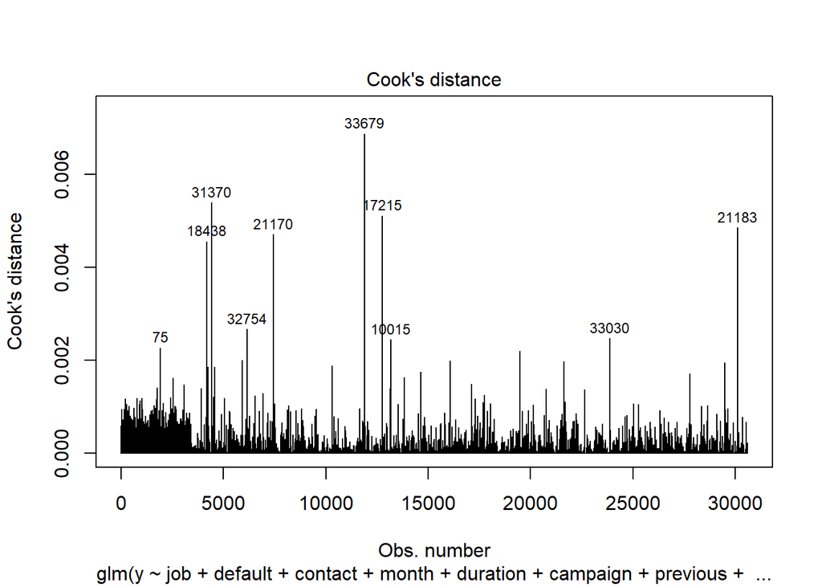

```r
plot(step.log, which = 4, id.n = 10) #Cooks D plot
```

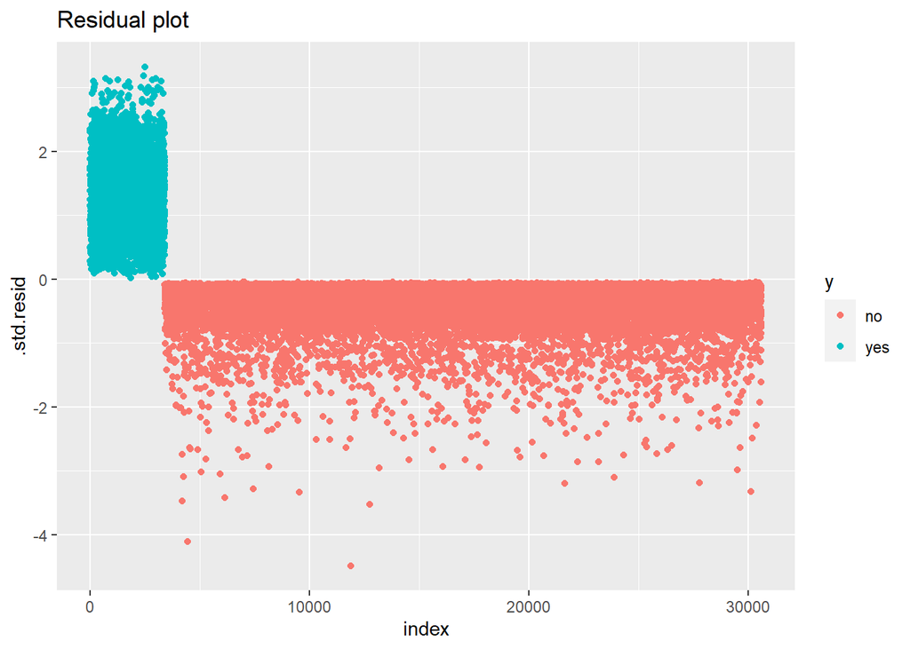

```r
#step.log.data
step.log.data <- augment(step.log) %>%
  mutate(index = 1:n())

ggplot(step.log.data, aes(index, .std.resid)) +
  geom_point(aes(color = y)) +
  ggtitle("Residual plot")
```

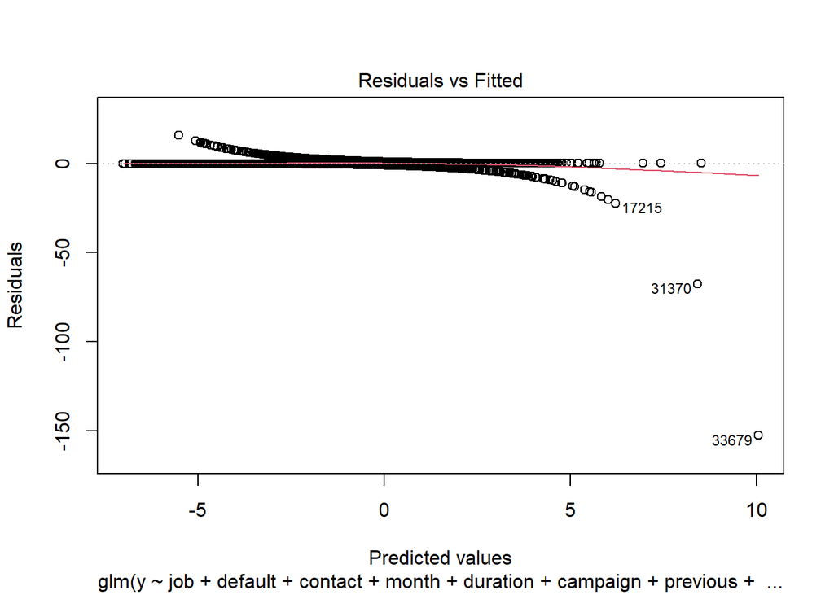

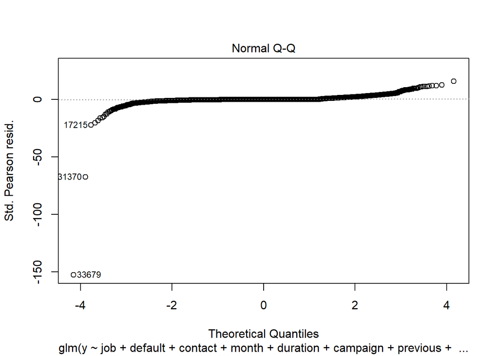

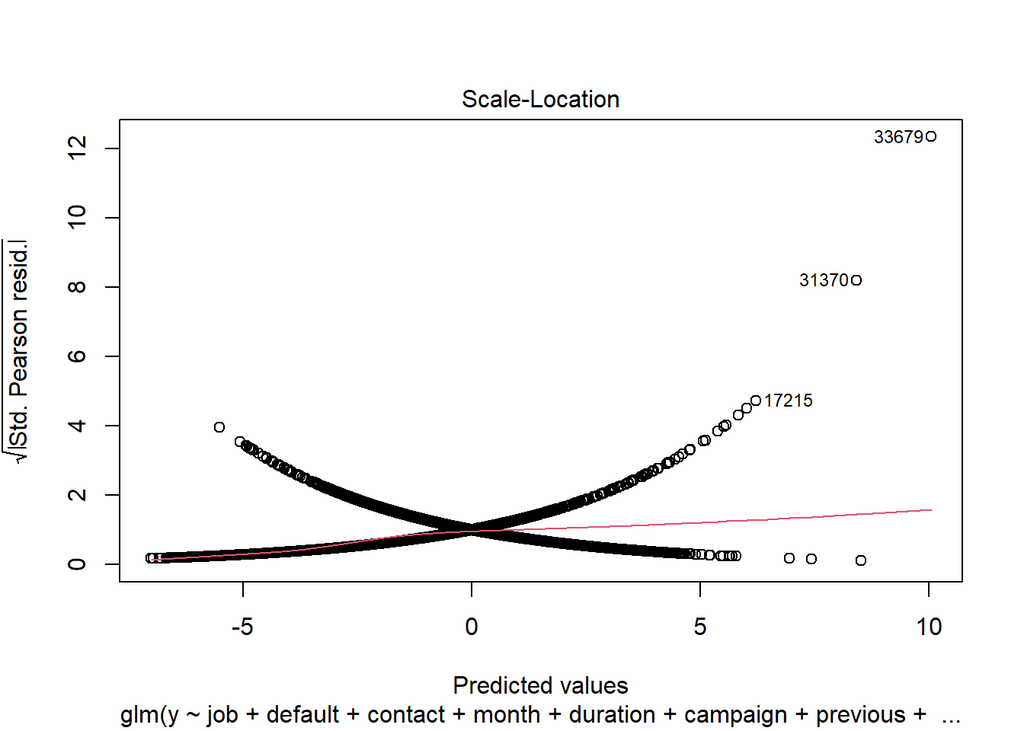

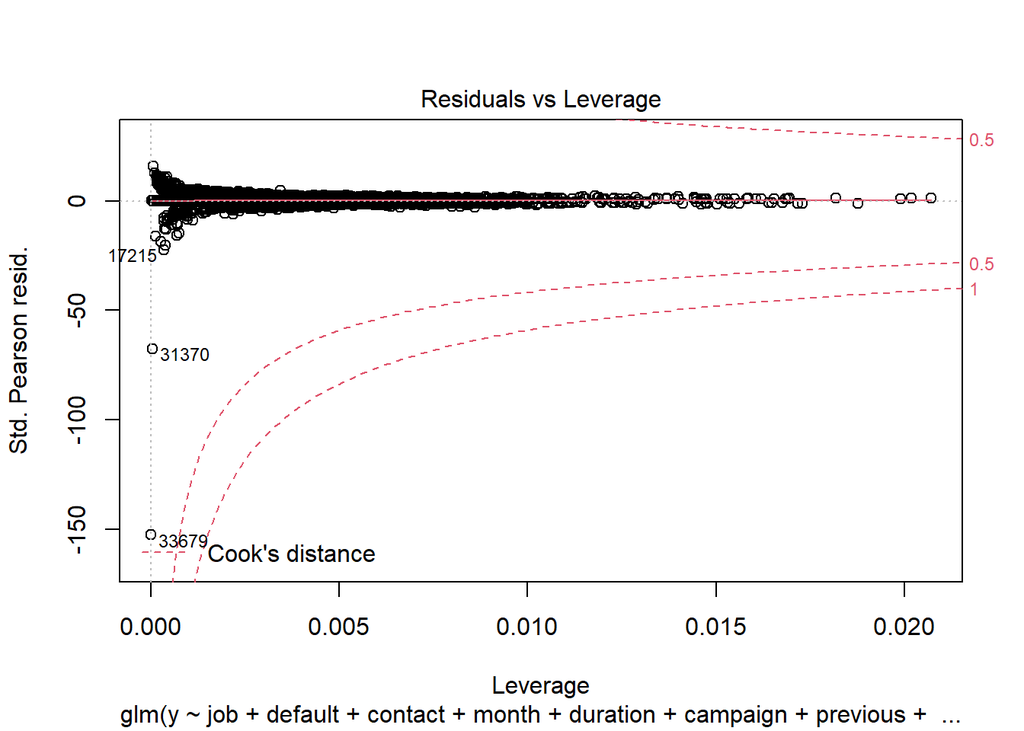

```r
#Residual diagnostics
plot(step.log)
```

```r
#examine outliers 1
nrow(train) #30593
```

```
## [1] 30593
```

```r
train2 <- train %>% dplyr::filter(!rownames(train) %in% c("17215","31370","33679"))
nrow(train2)
```

```
## [1] 30590
```

```r
#Residual diagnostics
step.log2 <- glm(
  y ~ job + default + contact + month + duration +
    campaign + previous + cons_price_idx + cons_conf_idx + euribor3m +
    Age_Grp + prevly_Cntctd + duration_group,
  family = "binomial",
  data = train2
)

#full.log<-glm(y~.,family="binomial",data=train)
summary(step.log2)
```

```
##
## Call:
## glm(formula = y ~ job + default + contact + month + duration +
##     campaign + previous + cons_price_idx + cons_conf_idx + euribor3m +
##     Age_Grp + prevly_Cntctd + duration_group, family = "binomial",
##     data = train2)
##
## Deviance Residuals:
##     Min       1Q   Median       3Q      Max
## -3.6185  -0.3015  -0.1734  -0.1207   3.3251
##
## Coefficients:
##                         Estimate Std. Error z value Pr(>|z|)
## (Intercept)           -4.793e+01  5.197e+00  -9.222  < 2e-16 ***
## jobblue-collar        -3.461e-01  7.589e-02  -4.560 5.11e-06 ***
## jobentrepreneur       -1.405e-01  1.423e-01  -0.987 0.323585
## jobhousemaid          -2.036e-01  1.683e-01  -1.210 0.226442
## jobmanagement         -4.160e-02  9.775e-02  -0.426 0.670403
## jobretired             8.181e-02  1.292e-01   0.633 0.526687
## jobself-employed      -1.145e-01  1.318e-01  -0.868 0.385200
## jobservices           -3.017e-01  9.532e-02  -3.165 0.001551 **
## jobstudent             1.689e-01  1.341e-01   1.259 0.207890
## jobtechnician         -7.230e-03  7.250e-02  -0.100 0.920555
## jobunemployed         -1.240e-01  1.537e-01  -0.806 0.419979
## defaultunknown        -3.301e-01  7.825e-02  -4.218 2.46e-05 ***
## contacttelephone      -3.629e-01  8.217e-02  -4.417 1.00e-05 ***
## monthaug               2.527e-01  1.200e-01   2.106 0.035190 *
## monthdec               5.577e-02  2.511e-01   0.222 0.824221
## monthjul               3.385e-01  1.114e-01   3.040 0.002365 **
## monthjun               3.970e-01  1.080e-01   3.676 0.000237 ***
## monthmar               1.747e+00  1.438e-01  12.154  < 2e-16 ***
## monthmay              -6.332e-01  8.882e-02  -7.129 1.01e-12 ***
## monthnov               7.351e-02  1.162e-01   0.633 0.526914
## monthoct               4.219e-01  1.473e-01   2.864 0.004188 **
## monthsep              -2.693e-03  1.605e-01  -0.017 0.986614
## duration               2.743e-03  1.621e-04  16.919  < 2e-16 ***
## campaign              -4.637e-02  1.329e-02  -3.488 0.000486 ***
## previous              -2.731e-01  4.754e-02  -5.744 9.25e-09 ***
## cons_price_idx         5.252e-01  5.708e-02   9.202  < 2e-16 ***
## cons_conf_idx          5.711e-02  6.137e-03   9.305  < 2e-16 ***
## euribor3m             -7.139e-01  2.232e-02 -31.982  < 2e-16 ***
## Age_Grp32-37          -1.931e-01  6.742e-02  -2.864 0.004186 **
## Age_Grp38-47          -3.038e-01  7.159e-02  -4.243 2.20e-05 ***
## Age_Grp47-55          -1.537e-01  8.000e-02  -1.921 0.054734 .
## Age_Grp>55            -7.966e-02  1.082e-01  -0.736 0.461683
## prevly_CntctdYes       1.826e+00  1.041e-01  17.542  < 2e-16 ***
## duration_group5-10min  1.041e+00  7.093e-02  14.679  < 2e-16 ***
## duration_group10+ min  1.836e+00  1.334e-01  13.760  < 2e-16 ***
## ---
## Signif. codes:  0 '***' 0.001 '**' 0.01 '*' 0.05 '.' 0.1 ' ' 1
##
## (Dispersion parameter for binomial family taken to be 1)
##
##     Null deviance: 21371  on 30589  degrees of freedom
## Residual deviance: 12486  on 30555  degrees of freedom
## AIC: 12556
##
## Number of Fisher Scoring iterations: 6
```

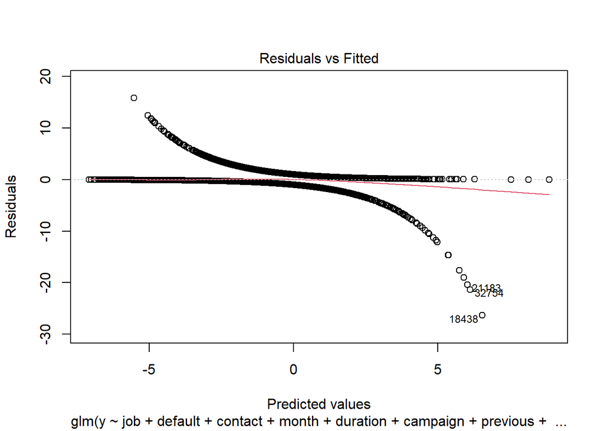

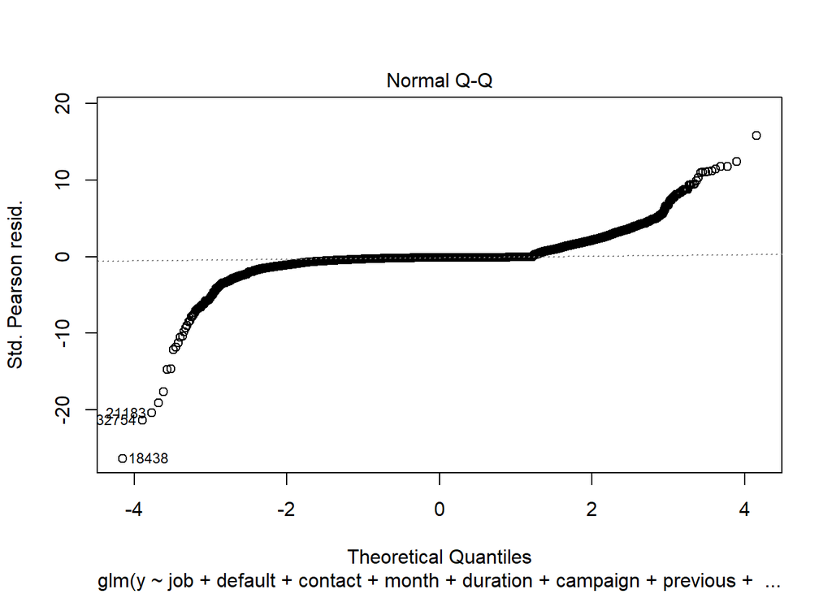

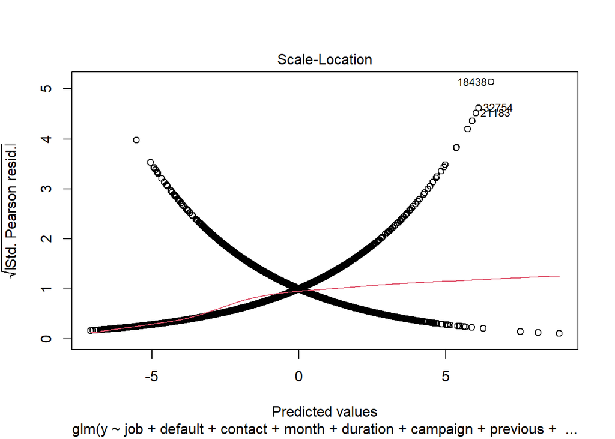

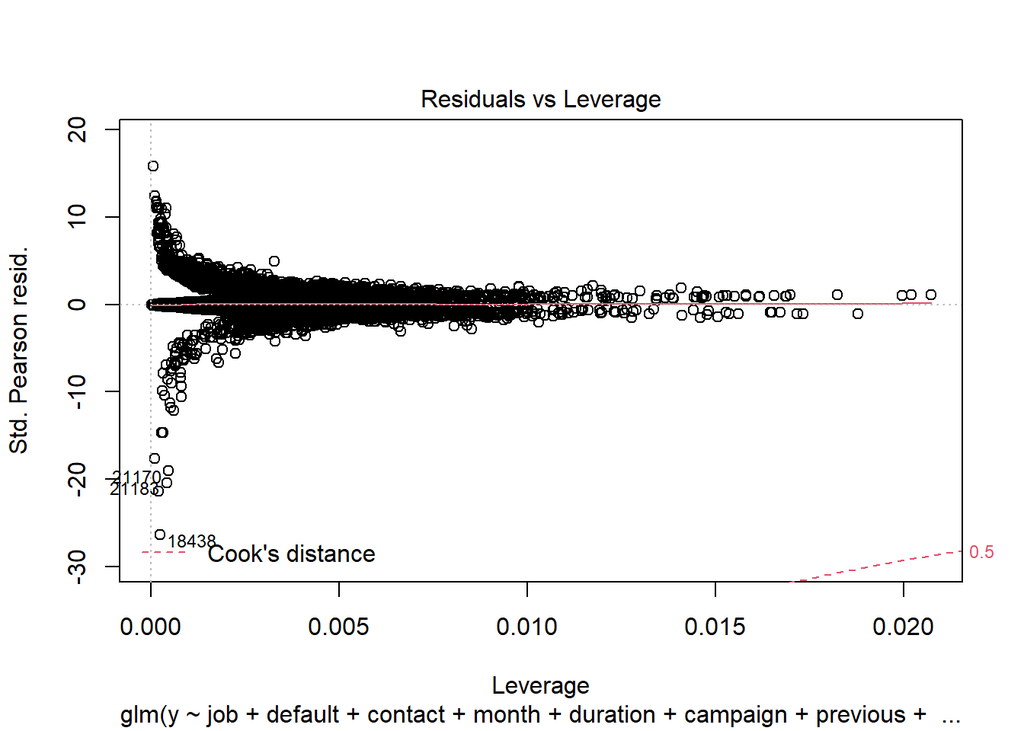

```r
plot(step.log2)
```

```r
#examine outliers 2
nrow(train2) #30590
```

```
## [1] 30590
```

```r
train3 <- train2 %>% dplyr::filter(!rownames(train2) %in% c("32754","18438","21183"))
nrow(train3)
```

```
## [1] 30587
```

```r
#Residual diagnostics
step.log3 <- glm(
  y ~ job + default + contact + month + duration +
    campaign + previous + cons_price_idx + cons_conf_idx + euribor3m +
    Age_Grp + prevly_Cntctd + duration_group,
  family = "binomial",
  data = train3
)

#full.log<-glm(y~.,family="binomial",data=train)
summary(step.log3)
```

```
##
## Call:
## glm(formula = y ~ job + default + contact + month + duration +
##     campaign + previous + cons_price_idx + cons_conf_idx + euribor3m +
##     Age_Grp + prevly_Cntctd + duration_group, family = "binomial",
##     data = train3)
##
## Deviance Residuals:
##     Min       1Q   Median       3Q      Max
## -3.5578  -0.3006  -0.1726  -0.1200   3.3267
##
## Coefficients:
##                         Estimate Std. Error z value Pr(>|z|)
## (Intercept)           -4.746e+01  5.197e+00  -9.131  < 2e-16 ***
## jobblue-collar        -3.459e-01  7.604e-02  -4.548 5.41e-06 ***
## jobentrepreneur       -1.445e-01  1.427e-01  -1.012 0.311356
## jobhousemaid          -1.831e-01  1.679e-01  -1.090 0.275583
## jobmanagement         -4.197e-02  9.791e-02  -0.429 0.668166
## jobretired             7.438e-02  1.294e-01   0.575 0.565434
## jobself-employed      -1.166e-01  1.321e-01  -0.883 0.377490
## jobservices           -3.037e-01  9.552e-02  -3.179 0.001477 **
## jobstudent             1.652e-01  1.342e-01   1.231 0.218408
## jobtechnician         -9.213e-03  7.264e-02  -0.127 0.899072
## jobunemployed         -1.257e-01  1.539e-01  -0.816 0.414230
## defaultunknown        -3.355e-01  7.851e-02  -4.273 1.93e-05 ***
## contacttelephone      -3.523e-01  8.221e-02  -4.285 1.82e-05 ***
## monthaug               2.628e-01  1.200e-01   2.189 0.028598 *
## monthdec               5.986e-02  2.510e-01   0.238 0.811513
## monthjul               3.409e-01  1.115e-01   3.057 0.002235 **
## monthjun               3.968e-01  1.081e-01   3.671 0.000242 ***
## monthmar               1.748e+00  1.438e-01  12.157  < 2e-16 ***
## monthmay              -6.363e-01  8.889e-02  -7.158 8.20e-13 ***
## monthnov               7.519e-02  1.163e-01   0.646 0.518044
## monthoct               4.526e-01  1.473e-01   3.073 0.002116 **
## monthsep               5.133e-03  1.606e-01   0.032 0.974501
## duration               2.907e-03  1.652e-04  17.599  < 2e-16 ***
## campaign              -4.734e-02  1.336e-02  -3.544 0.000394 ***
## previous              -2.737e-01  4.756e-02  -5.755 8.64e-09 ***
## cons_price_idx         5.196e-01  5.708e-02   9.102  < 2e-16 ***
## cons_conf_idx          5.643e-02  6.140e-03   9.191  < 2e-16 ***
## euribor3m             -7.147e-01  2.235e-02 -31.980  < 2e-16 ***
## Age_Grp32-37          -1.968e-01  6.753e-02  -2.914 0.003569 **
## Age_Grp38-47          -3.082e-01  7.173e-02  -4.297 1.73e-05 ***
## Age_Grp47-55          -1.527e-01  8.011e-02  -1.906 0.056592 .
## Age_Grp>55            -7.723e-02  1.083e-01  -0.713 0.475877
## prevly_CntctdYes       1.825e+00  1.041e-01  17.520  < 2e-16 ***
## duration_group5-10min  1.000e+00  7.140e-02  14.012  < 2e-16 ***
## duration_group10+ min  1.728e+00  1.348e-01  12.817  < 2e-16 ***
## ---
## Signif. codes:  0 '***' 0.001 '**' 0.01 '*' 0.05 '.' 0.1 ' ' 1
##
## (Dispersion parameter for binomial family taken to be 1)
##
##     Null deviance: 21370  on 30586  degrees of freedom
## Residual deviance: 12447  on 30552  degrees of freedom
## AIC: 12517
##
## Number of Fisher Scoring iterations: 6
```

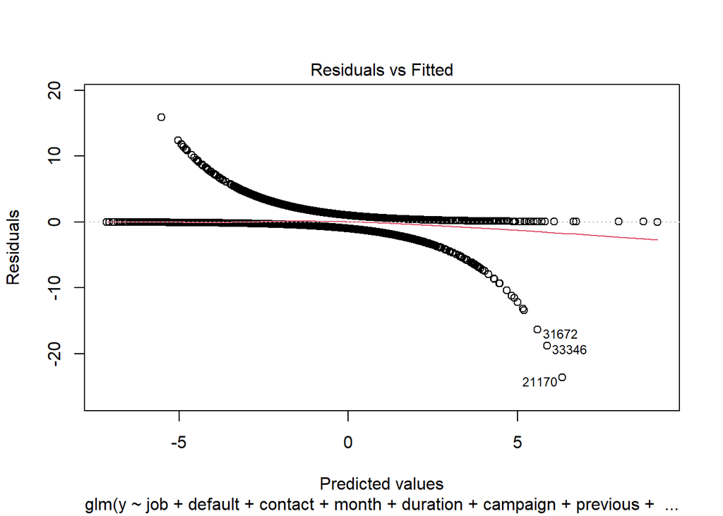

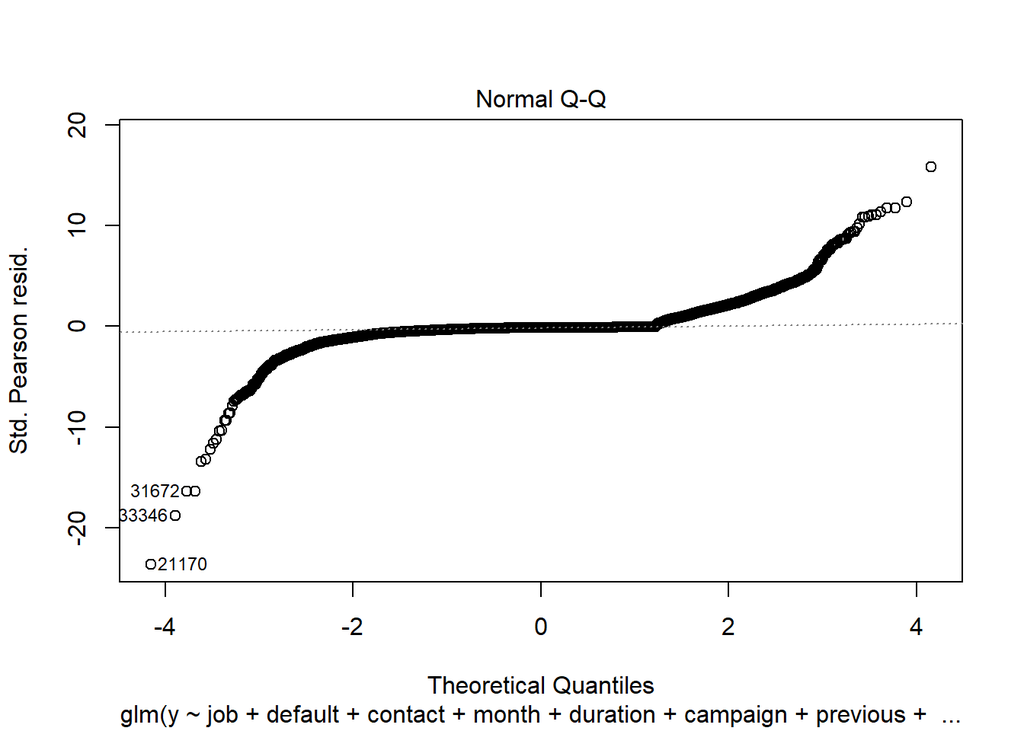

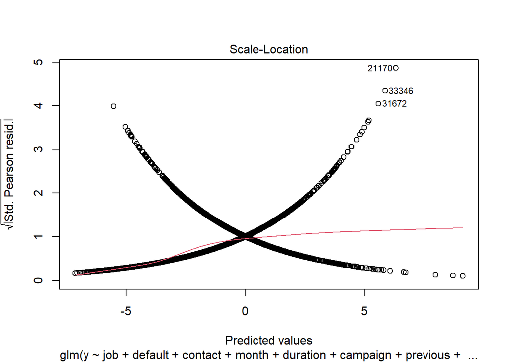

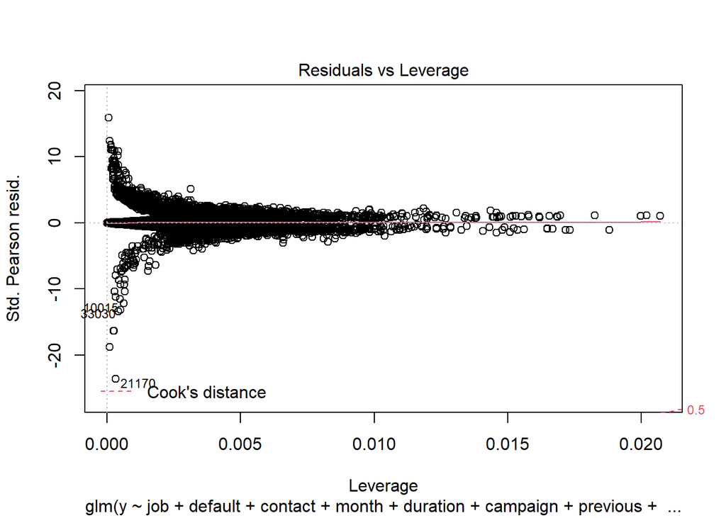

```r
plot(step.log3)
```

Check what the outliers are

```r
train %>% dplyr::filter(rownames(train) %in% c("17215", "31370", "33679", "32754", "18438", "21183")) %>% dplyr::select(
  y,
  job,
  default,
  contact,
  month,
  duration,
  campaign,
  previous,
  cons_price_idx,
  cons_conf_idx,
  euribor3m,
  Age_Grp,
  prevly_Cntctd,
  duration_group
)
```

```
##        y         job default   contact month duration campaign previous
## 18438 no      admin.      no  cellular   aug     3322        1        0
## 31370 no blue-collar      no  cellular   may     3509        2        2
## 32754 no   housemaid      no telephone   oct     2187        1        0
## 33679 no      admin.      no telephone   aug     3785        1        0
## 17215 no  management      no  cellular   aug     3422        1        0
## 21183 no blue-collar      no telephone   oct     3284        1        0
##       cons_price_idx cons_conf_idx euribor3m Age_Grp prevly_Cntctd
## 18438         93.444         -36.1     4.964   47-55            No
## 31370         92.893         -46.2     1.266   17-31           Yes
## 32754         92.431         -26.9     0.737     >55            No
## 33679         94.027         -38.3     0.888   17-31            No
## 17215         93.444         -36.1     4.968   47-55            No
## 21183         93.798         -40.4     4.912   17-31            No
##       duration_group
## 18438        10+ min
## 31370        10+ min
## 32754        10+ min
## 33679        10+ min
## 17215        10+ min
## 21183        10+ min
```

Check if metrics change at all with the reduced model to determine if it’s worth removing outliers. No significant changes in coefficients and AIC only reduces slightly.

```r
fit.pred.step_outlier<-predict(step.log3,newdata=test,type="response")
class.step_out<-factor(ifelse(fit.pred.step_outlier>0.5,"yes","no"),levels=c("no","yes"))

# use caret and compute a confusion matrix
confusionMatrix(class.step_out,test$y, positive = "yes")
```

```
## Confusion Matrix and Statistics
##
##           Reference
## Prediction   no  yes
##        no  6608  471
##        yes  189  381
##
##                Accuracy : 0.9137
##                  95% CI : (0.9072, 0.9199)
##     No Information Rate : 0.8886
##     P-Value [Acc > NIR] : 2.83e-13
##
##                   Kappa : 0.4904
##
##  Mcnemar's Test P-Value : < 2.2e-16
##
##             Sensitivity : 0.44718
##             Specificity : 0.97219
##          Pos Pred Value : 0.66842
##          Neg Pred Value : 0.93347
##              Prevalence : 0.11139
##          Detection Rate : 0.04981
##    Detection Prevalence : 0.07452
##       Balanced Accuracy : 0.70969
##
##        'Positive' Class : yes
##
```

No real change. OK to keep outliers in the model.

# Complex Logistic Model

Run Initial Logistic Regression allowing for interaction

```r
#computer memory issues - start with only one added interaction
complex.log <-
  glm(
    y ~ job + default + contact + month + duration + campaign +
      previous + cons_price_idx + cons_conf_idx + euribor3m +
      Age_Grp + prevly_Cntctd + duration_group + duration * default,
    family = "binomial",
    data = train
  )
summary(complex.log)
```

```
##
## Call:
## glm(formula = y ~ job + default + contact + month + duration +
##     campaign + previous + cons_price_idx + cons_conf_idx + euribor3m +
##     Age_Grp + prevly_Cntctd + duration_group + duration * default,
##     family = "binomial", data = train)
##
## Deviance Residuals:
##     Min       1Q   Median       3Q      Max
## -4.2540  -0.3004  -0.1762  -0.1079   3.5076
##
## Coefficients:
##                           Estimate Std. Error z value Pr(>|z|)
## (Intercept)             -4.703e+01  5.183e+00  -9.074  < 2e-16 ***
## jobblue-collar          -3.525e-01  7.601e-02  -4.637 3.53e-06 ***
## jobentrepreneur         -1.456e-01  1.417e-01  -1.027 0.304298
## jobhousemaid            -1.867e-01  1.686e-01  -1.108 0.268046
## jobmanagement           -4.556e-02  9.724e-02  -0.469 0.639400
## jobretired               7.521e-02  1.297e-01   0.580 0.562028
## jobself-employed        -1.174e-01  1.316e-01  -0.892 0.372539
## jobservices             -2.995e-01  9.505e-02  -3.151 0.001628 **
## jobstudent               1.687e-01  1.337e-01   1.262 0.207063
## jobtechnician           -9.495e-03  7.204e-02  -0.132 0.895137
## jobunemployed           -1.301e-01  1.534e-01  -0.848 0.396525
## defaultunknown          -1.319e+00  1.669e-01  -7.900 2.78e-15 ***
## contacttelephone        -3.872e-01  8.203e-02  -4.721 2.35e-06 ***
## monthaug                 2.212e-01  1.197e-01   1.848 0.064627 .
## monthdec                 5.879e-02  2.500e-01   0.235 0.814102
## monthjul                 3.216e-01  1.110e-01   2.897 0.003764 **
## monthjun                 3.820e-01  1.077e-01   3.547 0.000389 ***
## monthmar                 1.726e+00  1.428e-01  12.086  < 2e-16 ***
## monthmay                -6.342e-01  8.851e-02  -7.165 7.79e-13 ***
## monthnov                 5.860e-02  1.155e-01   0.507 0.611832
## monthoct                 4.087e-01  1.469e-01   2.783 0.005387 **
## monthsep                -1.531e-02  1.599e-01  -0.096 0.923708
## duration                 2.246e-03  1.598e-04  14.050  < 2e-16 ***
## campaign                -4.499e-02  1.322e-02  -3.403 0.000665 ***
## previous                -2.665e-01  4.736e-02  -5.628 1.82e-08 ***
## cons_price_idx           5.163e-01  5.692e-02   9.069  < 2e-16 ***
## cons_conf_idx            5.606e-02  6.122e-03   9.157  < 2e-16 ***
## euribor3m               -6.988e-01  2.223e-02 -31.433  < 2e-16 ***
## Age_Grp32-37            -1.933e-01  6.703e-02  -2.883 0.003934 **
## Age_Grp38-47            -2.979e-01  7.134e-02  -4.176 2.96e-05 ***
## Age_Grp47-55            -1.518e-01  7.986e-02  -1.902 0.057235 .
## Age_Grp>55              -5.958e-02  1.084e-01  -0.550 0.582506
## prevly_CntctdYes         1.815e+00  1.038e-01  17.493  < 2e-16 ***
## duration_group5-10min    1.144e+00  7.069e-02  16.182  < 2e-16 ***
## duration_group10+ min    2.014e+00  1.317e-01  15.295  < 2e-16 ***
## defaultunknown:duration  1.729e-03  2.419e-04   7.148 8.80e-13 ***
## ---
## Signif. codes:  0 '***' 0.001 '**' 0.01 '*' 0.05 '.' 0.1 ' ' 1
##
## (Dispersion parameter for binomial family taken to be 1)
##
##     Null deviance: 21372  on 30592  degrees of freedom
## Residual deviance: 12478  on 30557  degrees of freedom
## AIC: 12550
##
## Number of Fisher Scoring iterations: 7
```

```r
#exp(cbind("Odds ratio" = coef(complex.log), confint.default(complex.log, level = 0.95)))
```

Testing for some interactions based on EDA

```r
complex.log <-
  glm(
    y ~ job + default + contact + month + duration + campaign +
      previous + cons_price_idx + cons_conf_idx + euribor3m +
      Age_Grp + prevly_Cntctd + duration_group + Age_Grp * education + campaign *
      duration + cons_price_idx * euribor3m + month * euribor3m,
    family = "binomial",
    data = train
  )
summary(complex.log)
```

```
##
## Call:
## glm(formula = y ~ job + default + contact + month + duration +
##     campaign + previous + cons_price_idx + cons_conf_idx + euribor3m +
##     Age_Grp + prevly_Cntctd + duration_group + Age_Grp * education +
##     campaign * duration + cons_price_idx * euribor3m + month *
##     euribor3m, family = "binomial", data = train)
##
## Deviance Residuals:
##     Min       1Q   Median       3Q      Max
## -4.3666  -0.2915  -0.1614  -0.1138   3.2713
##
## Coefficients: (2 not defined because of singularities)
##                                             Estimate Std. Error z value
## (Intercept)                               -1.158e+02  4.544e+01  -2.548
## jobblue-collar                            -2.074e-01  9.648e-02  -2.150
## jobentrepreneur                           -1.081e-01  1.451e-01  -0.745
## jobhousemaid                              -1.572e-01  1.791e-01  -0.878
## jobmanagement                             -8.738e-02  1.005e-01  -0.869
## jobretired                                 8.941e-02  1.357e-01   0.659
## jobself-employed                          -1.469e-01  1.347e-01  -1.090
## jobservices                               -1.717e-01  1.014e-01  -1.693
## jobstudent                                 1.712e-01  1.407e-01   1.217
## jobtechnician                              1.850e-02  8.278e-02   0.223
## jobunemployed                             -1.836e-02  1.571e-01  -0.117
## defaultunknown                            -2.734e-01  7.953e-02  -3.438
## contacttelephone                          -5.725e-01  9.870e-02  -5.801
## monthaug                                   3.082e-01  5.606e-01   0.550
## monthdec                                   3.861e+01  3.332e+01   1.159
## monthjul                                   1.787e-01  4.752e-01   0.376
## monthjun                                   3.173e-01  5.571e-01   0.570
## monthmar                                  -7.670e-01  5.416e-01  -1.416
## monthmay                                  -7.036e-01  5.542e-01  -1.270
## monthnov                                   3.596e-01  6.079e-01   0.592
## monthoct                                  -1.103e+00  5.051e-01  -2.184
## monthsep                                   1.363e+00  2.665e+00   0.512
## duration                                   2.044e-03  1.838e-04  11.121
## campaign                                  -1.464e-01  2.568e-02  -5.701
## previous                                  -2.719e-01  4.805e-02  -5.659
## cons_price_idx                             1.268e+00  4.889e-01   2.593
```

[output cut: 122 more lines]

```
## monthmar:euribor3m                        9.33e-07 ***
## monthmay:euribor3m                        0.954503
## monthnov:euribor3m                        0.447411
## monthoct:euribor3m                        0.002408 **
## monthsep:euribor3m                        0.508166
## ---
## Signif. codes:  0 '***' 0.001 '**' 0.01 '*' 0.05 '.' 0.1 ' ' 1
##
## (Dispersion parameter for binomial family taken to be 1)
##
##     Null deviance: 21372  on 30592  degrees of freedom
## Residual deviance: 12220  on 30519  degrees of freedom
## AIC: 12368
##
## Number of Fisher Scoring iterations: 10
```

```r
#exp(cbind("Odds ratio" = coef(complex.log), confint.default(complex.log, level = 0.95)))
#complex.pred <- predict(complex.log, newdata = test, type="response")
```

Duration and campaign is significant but has a small coefficient/odds ratio. Month and euribor3m are significant as an interaction term with some odds ratios being very large. Education and age group is not significant for interaction. We also likely don’t want to use education for any interaction due to no observations falling into that group.

# Additional EDA for interaction

Let’s run some more EDA with specific focus on our variables from the stepwise model.

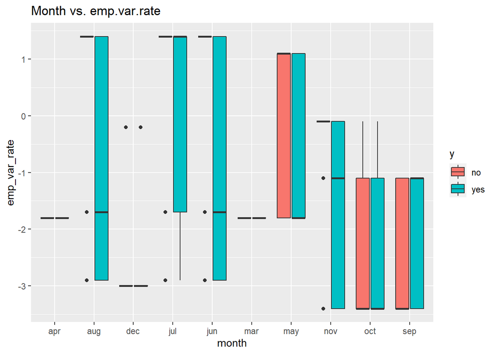

```r
#numerical y vars
ggplot(df, aes(x=month , y=emp_var_rate, fill = y)) +
  geom_boxplot() +
  ggtitle("Month vs. emp.var.rate")
```

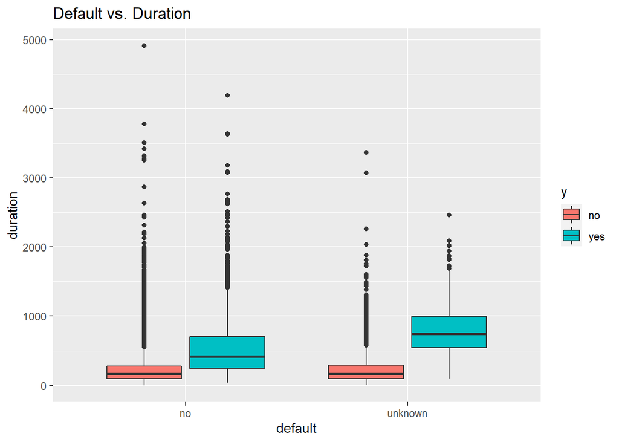

```r
ggplot(df, aes(x=default , y=duration, fill = y)) +
  geom_boxplot() +
  ggtitle("Default vs. Duration")
```

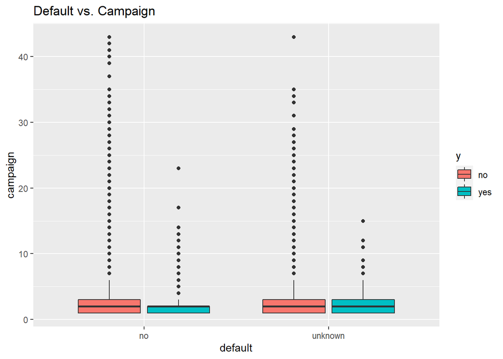

```r
ggplot(df, aes(x=default , y=campaign, fill = y)) +
  geom_boxplot() +
  ggtitle("Default vs. Campaign")
```

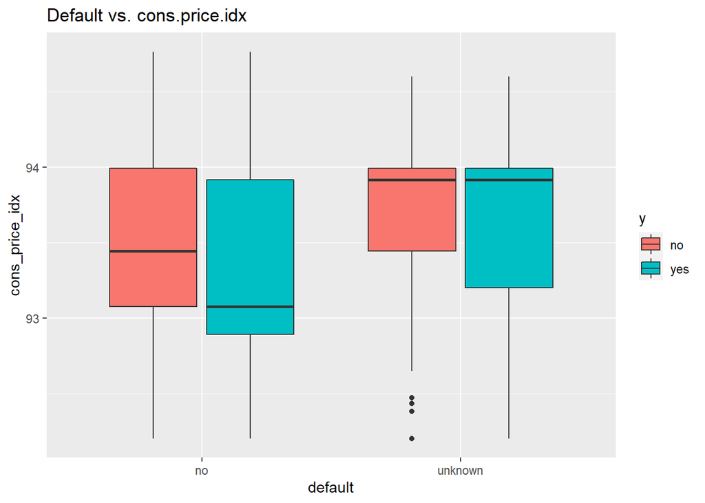

```r
ggplot(df, aes(x=default , y=cons_price_idx, fill = y)) +
  geom_boxplot() +
  ggtitle("Default vs. cons.price.idx")
```

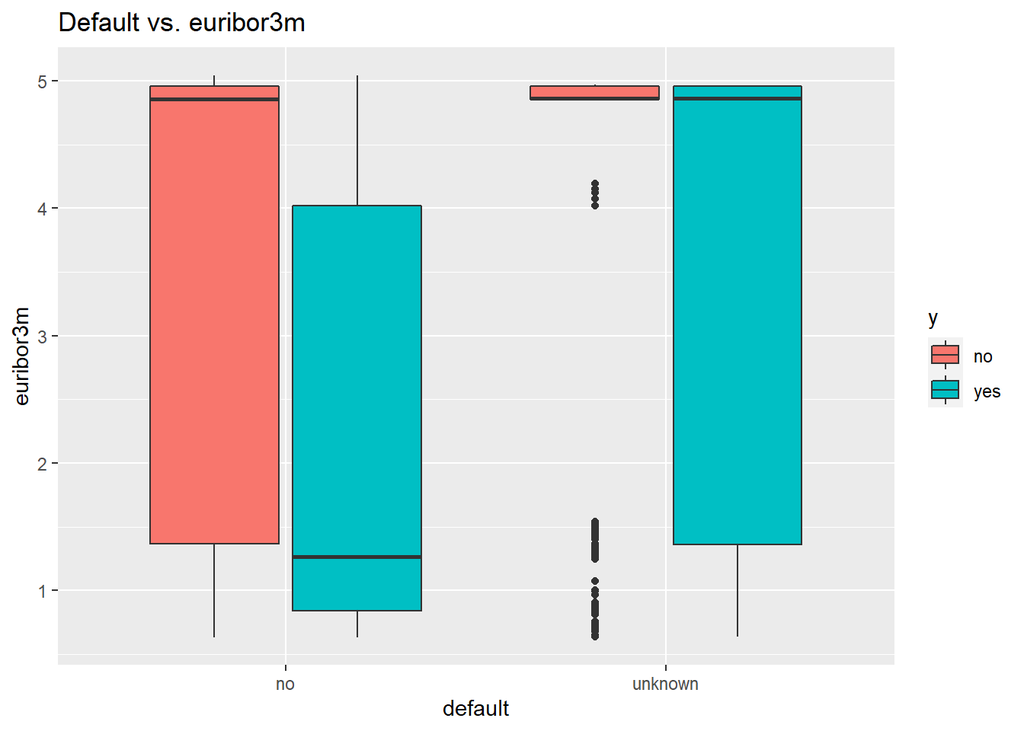

```r
ggplot(df, aes(x=default , y=euribor3m, fill = y)) +
  geom_boxplot() +
  ggtitle("Default vs. euribor3m")
```

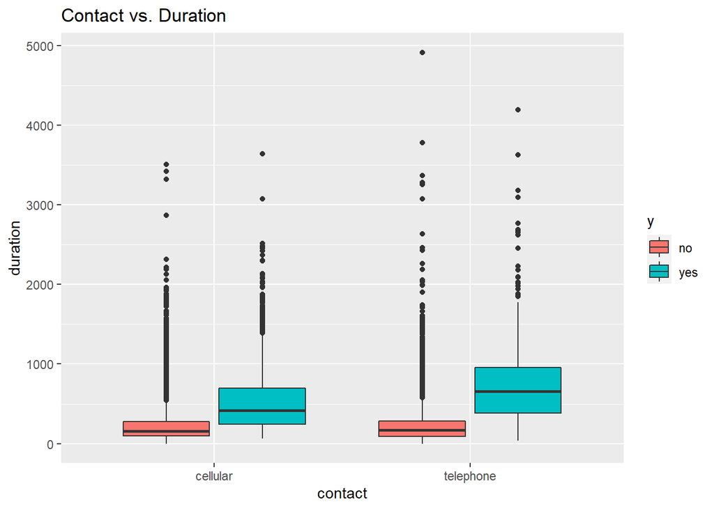

```r
ggplot(df, aes(x=contact , y=duration, fill = y)) +
  geom_boxplot() +
  ggtitle("Contact vs. Duration")
```

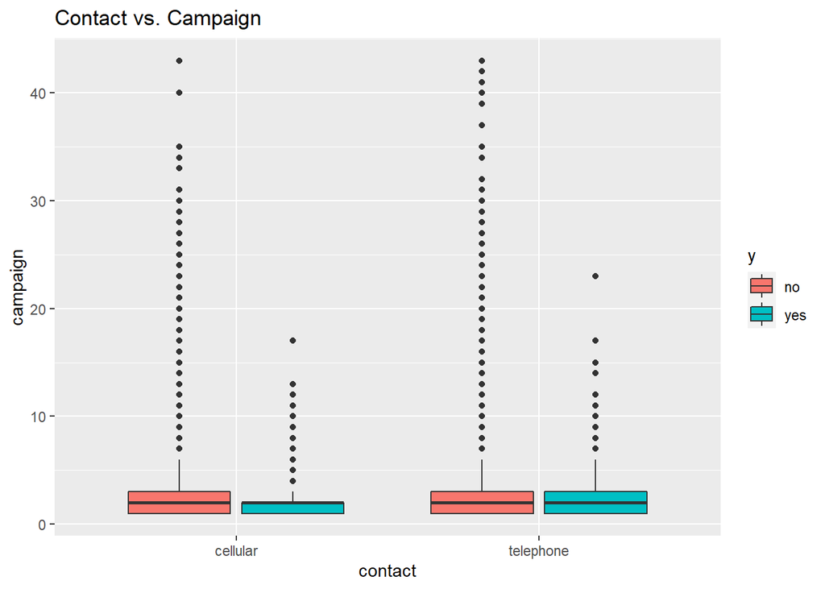

```r
ggplot(df, aes(x=contact , y=campaign, fill = y)) +
  geom_boxplot() +
  ggtitle("Contact vs. Campaign")
```

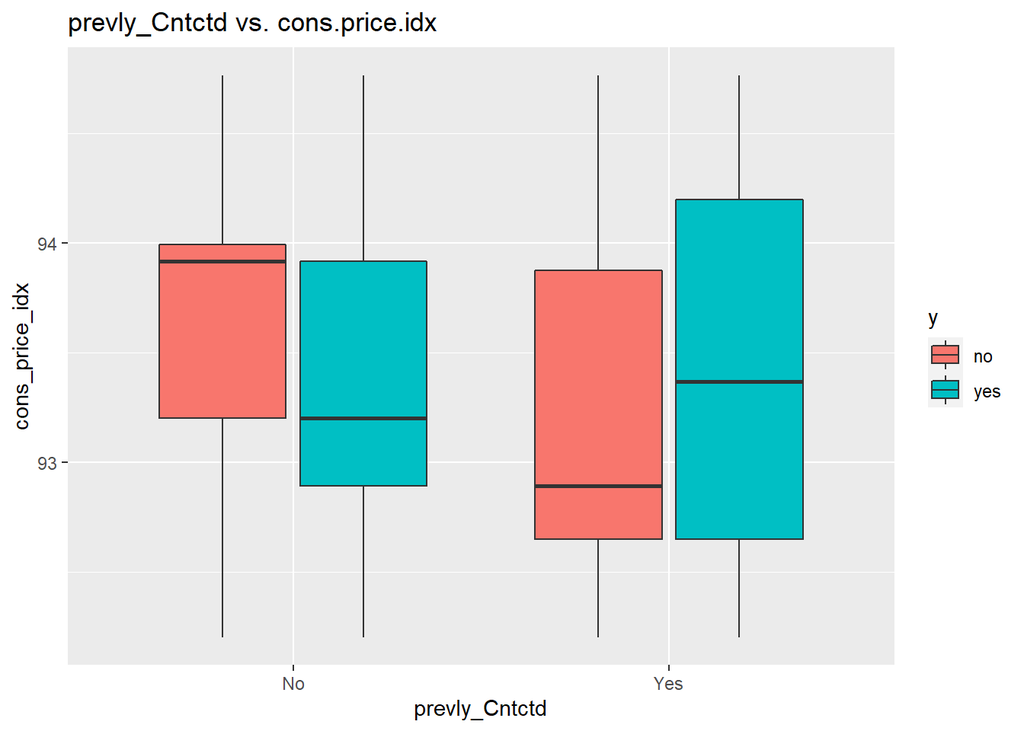

```r
ggplot(df, aes(x=prevly_Cntctd , y=cons_price_idx, fill = y)) +
  geom_boxplot() +
  ggtitle("prevly_Cntctd vs. cons.price.idx")
```

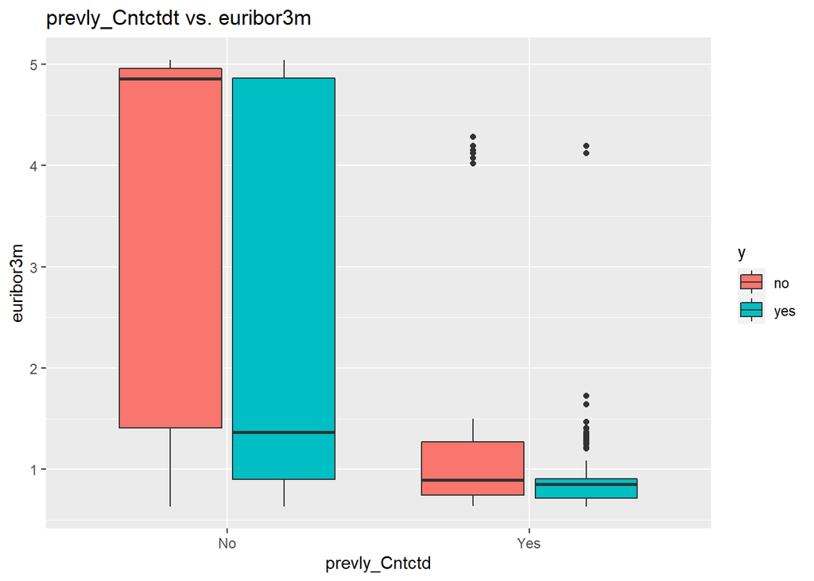

```r
ggplot(df, aes(x=prevly_Cntctd , y=euribor3m, fill = y)) +
  geom_boxplot() +
  ggtitle("prevly_Cntctdt vs. euribor3m")
```

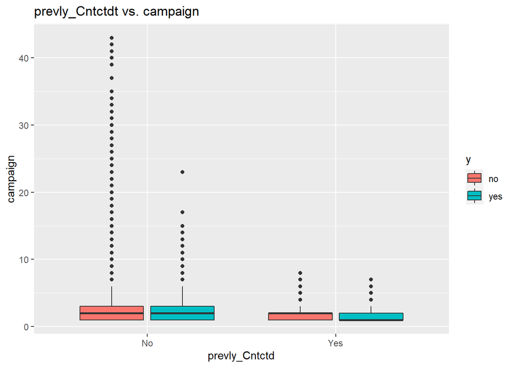

```r
ggplot(df, aes(x=prevly_Cntctd , y=campaign, fill = y)) +
  geom_boxplot() +
  ggtitle("prevly_Cntctdt vs. campaign")
```

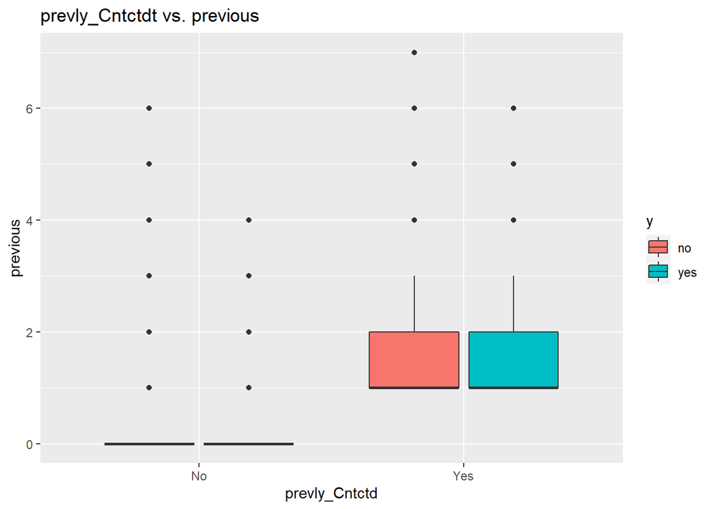

```r
ggplot(df, aes(x=prevly_Cntctd , y=previous, fill = y)) +
  geom_boxplot() +
  ggtitle("prevly_Cntctdt vs. previous")
```

```r
#tables for categoricals
prop.table(table(df_yes$default,df_yes$month),2)
```

```
##
##                  apr        aug        dec        jul        jun        mar
##   no      0.96296296 0.89429530 0.96103896 0.85475793 0.88454012 0.97619048
##   unknown 0.03703704 0.10570470 0.03896104 0.14524207 0.11545988 0.02380952
##
##                  may        nov        oct        sep
##   no      0.84337349 0.94805195 0.96632997 0.98666667
##   unknown 0.15662651 0.05194805 0.03367003 0.01333333
```

```r
prop.table(table(df_No$y,df_No$month),2)
```

```
##
##       apr aug dec jul jun mar may nov oct sep
##   no    1   1   1   1   1   1   1   1   1   1
##   yes   0   0   0   0   0   0   0   0   0   0
```

Add in some interactions based on what we see from these charts: default/duration, contact/duration, default/month and keeping in month/euribor3m

```r
complex.log <-
  glm(
    y ~ job + default + contact + month + duration + campaign +
      previous + cons_price_idx + cons_conf_idx + euribor3m +
      Age_Grp + prevly_Cntctd + duration_group + default *
      duration + contact * duration + default * month + month * euribor3m,
    family = "binomial",
    data = train
  )
summary(complex.log)
```

```
##
## Call:
## glm(formula = y ~ job + default + contact + month + duration +
##     campaign + previous + cons_price_idx + cons_conf_idx + euribor3m +
##     Age_Grp + prevly_Cntctd + duration_group + default * duration +
##     contact * duration + default * month + month * euribor3m,
##     family = "binomial", data = train)
##
## Deviance Residuals:
##     Min       1Q   Median       3Q      Max
## -4.7860  -0.2907  -0.1637  -0.0999   3.5331
##
## Coefficients:
##                             Estimate Std. Error z value Pr(>|z|)
## (Intercept)               -6.313e+01  7.540e+00  -8.372  < 2e-16 ***
## jobblue-collar            -3.049e-01  7.692e-02  -3.964 7.37e-05 ***
## jobentrepreneur           -1.487e-01  1.442e-01  -1.031 0.302526
## jobhousemaid              -1.942e-01  1.711e-01  -1.135 0.256263
## jobmanagement             -4.135e-02  9.846e-02  -0.420 0.674512
## jobretired                 5.670e-02  1.310e-01   0.433 0.665166
## jobself-employed          -9.699e-02  1.320e-01  -0.735 0.462549
## jobservices               -2.508e-01  9.597e-02  -2.613 0.008963 **
## jobstudent                 1.053e-01  1.354e-01   0.778 0.436833
## jobtechnician             -7.349e-03  7.280e-02  -0.101 0.919593
## jobunemployed             -9.814e-02  1.547e-01  -0.634 0.525803
## defaultunknown            -2.498e+00  3.965e-01  -6.301 2.97e-10 ***
## contacttelephone          -8.919e-01  1.194e-01  -7.469 8.11e-14 ***
## monthaug                   2.267e-02  4.707e-01   0.048 0.961585
## monthdec                   4.625e+01  3.348e+01   1.382 0.167108
## monthjul                   2.144e-01  4.713e-01   0.455 0.649218
## monthjun                   7.549e-01  4.944e-01   1.527 0.126749
## monthmar                  -8.752e-01  4.989e-01  -1.754 0.079432 .
## monthmay                  -5.930e-01  5.487e-01  -1.081 0.279827
## monthnov                  -6.922e-02  4.668e-01  -0.148 0.882120
## monthoct                  -1.306e+00  4.646e-01  -2.811 0.004939 **
## monthsep                  -4.590e-01  2.249e+00  -0.204 0.838292
## duration                   1.984e-03  1.709e-04  11.613  < 2e-16 ***
## campaign                  -4.119e-02  1.337e-02  -3.081 0.002066 **
## previous                  -2.695e-01  4.770e-02  -5.650 1.61e-08 ***
## cons_price_idx             7.057e-01  8.200e-02   8.607  < 2e-16 ***
```

[output cut: 24 more lines]

```
## monthmar:euribor3m         2.113e+00  3.759e-01   5.620 1.91e-08 ***
## monthmay:euribor3m        -1.312e-01  4.030e-01  -0.325 0.744805
## monthnov:euribor3m        -7.810e-02  3.657e-01  -0.214 0.830900
## monthoct:euribor3m         1.242e+00  3.794e-01   3.273 0.001062 **
## monthsep:euribor3m         1.686e-02  2.662e+00   0.006 0.994947
## ---
## Signif. codes:  0 '***' 0.001 '**' 0.01 '*' 0.05 '.' 0.1 ' ' 1
##
## (Dispersion parameter for binomial family taken to be 1)
##
##     Null deviance: 21372  on 30592  degrees of freedom
## Residual deviance: 12181  on 30538  degrees of freedom
## AIC: 12291
##
## Number of Fisher Scoring iterations: 10
```

Default being unknown seems to carry some sort of significance in our model. We are keeping it in as we are not counting it as ‘missing’ but moreso as an actual ‘unknown’ value.

### Run step-wise selection on this model

```r
step.complex<-complex.log %>% stepAIC(trace=FALSE)
summary(step.complex)
```

```
##
## Call:
## glm(formula = y ~ job + default + contact + month + duration +
##     campaign + previous + cons_price_idx + cons_conf_idx + euribor3m +
##     Age_Grp + prevly_Cntctd + duration_group + default * duration +
##     contact * duration + default * month + month * euribor3m,
##     family = "binomial", data = train)
##
## Deviance Residuals:
##     Min       1Q   Median       3Q      Max
## -4.7860  -0.2907  -0.1637  -0.0999   3.5331
##
## Coefficients:
##                             Estimate Std. Error z value Pr(>|z|)
## (Intercept)               -6.313e+01  7.540e+00  -8.372  < 2e-16 ***
## jobblue-collar            -3.049e-01  7.692e-02  -3.964 7.37e-05 ***
## jobentrepreneur           -1.487e-01  1.442e-01  -1.031 0.302526
## jobhousemaid              -1.942e-01  1.711e-01  -1.135 0.256263
## jobmanagement             -4.135e-02  9.846e-02  -0.420 0.674512
## jobretired                 5.670e-02  1.310e-01   0.433 0.665166
## jobself-employed          -9.699e-02  1.320e-01  -0.735 0.462549
## jobservices               -2.508e-01  9.597e-02  -2.613 0.008963 **
## jobstudent                 1.053e-01  1.354e-01   0.778 0.436833
## jobtechnician             -7.349e-03  7.280e-02  -0.101 0.919593
## jobunemployed             -9.814e-02  1.547e-01  -0.634 0.525803
## defaultunknown            -2.498e+00  3.965e-01  -6.301 2.97e-10 ***
## contacttelephone          -8.919e-01  1.194e-01  -7.469 8.11e-14 ***
## monthaug                   2.267e-02  4.707e-01   0.048 0.961585
## monthdec                   4.625e+01  3.348e+01   1.382 0.167108
## monthjul                   2.144e-01  4.713e-01   0.455 0.649218
## monthjun                   7.549e-01  4.944e-01   1.527 0.126749
## monthmar                  -8.752e-01  4.989e-01  -1.754 0.079432 .
## monthmay                  -5.930e-01  5.487e-01  -1.081 0.279827
## monthnov                  -6.922e-02  4.668e-01  -0.148 0.882120
## monthoct                  -1.306e+00  4.646e-01  -2.811 0.004939 **
## monthsep                  -4.590e-01  2.249e+00  -0.204 0.838292
## duration                   1.984e-03  1.709e-04  11.613  < 2e-16 ***
## campaign                  -4.119e-02  1.337e-02  -3.081 0.002066 **
## previous                  -2.695e-01  4.770e-02  -5.650 1.61e-08 ***
## cons_price_idx             7.057e-01  8.200e-02   8.607  < 2e-16 ***
```

[output cut: 24 more lines]

```
## monthmar:euribor3m         2.113e+00  3.759e-01   5.620 1.91e-08 ***
## monthmay:euribor3m        -1.312e-01  4.030e-01  -0.325 0.744805
## monthnov:euribor3m        -7.810e-02  3.657e-01  -0.214 0.830900
## monthoct:euribor3m         1.242e+00  3.794e-01   3.273 0.001062 **
## monthsep:euribor3m         1.686e-02  2.662e+00   0.006 0.994947
## ---
## Signif. codes:  0 '***' 0.001 '**' 0.01 '*' 0.05 '.' 0.1 ' ' 1
##
## (Dispersion parameter for binomial family taken to be 1)
##
##     Null deviance: 21372  on 30592  degrees of freedom
## Residual deviance: 12181  on 30538  degrees of freedom
## AIC: 12291
##
## Number of Fisher Scoring iterations: 10
```

#Check metrics with standard 0.5 accuracy and our 0.15 accuracy for complex log model

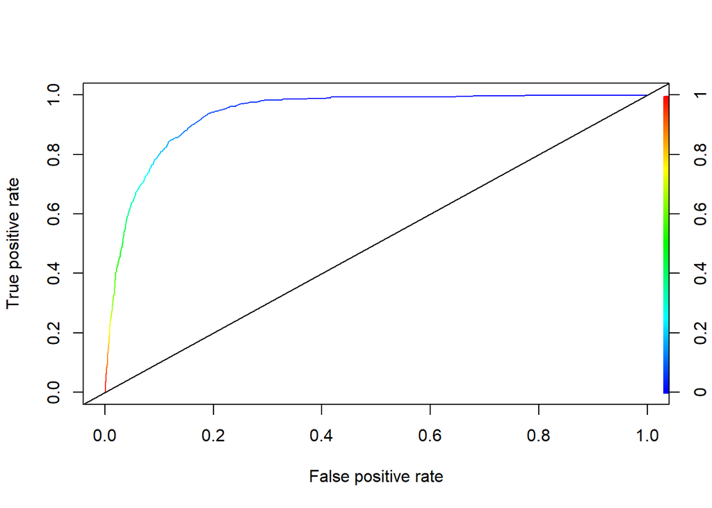

```r
complex.pred <- predict(step.complex, newdata = test, type="response")

#ROCR
results.complex<-prediction(complex.pred, test$y,label.ordering=c("no","yes"))
roc.complex = performance(results.complex, measure = "tpr", x.measure = "fpr")
plot(roc.complex,colorize = TRUE)
abline(a=0, b= 1)
```

```r
cutoff<-0.5
class.complex<-factor(ifelse(complex.pred>cutoff,"yes","no"),levels=c("no","yes"))

#Confusion Matrix
conf.complex<-table(class.complex,test$y)
conf.complex
```

```
##
## class.complex   no  yes
##           no  6608  463
##           yes  189  389
```

```r
complex<-confusionMatrix(conf.complex, positive = "yes")
complex
```

```
## Confusion Matrix and Statistics
##
##
## class.complex   no  yes
##           no  6608  463
##           yes  189  389
##
##                Accuracy : 0.9148
##                  95% CI : (0.9083, 0.9209)
##     No Information Rate : 0.8886
##     P-Value [Acc > NIR] : 2.695e-14
##
##                   Kappa : 0.4989
##
##  Mcnemar's Test P-Value : < 2.2e-16
##
##             Sensitivity : 0.45657
##             Specificity : 0.97219
##          Pos Pred Value : 0.67301
##          Neg Pred Value : 0.93452
##              Prevalence : 0.11139
##          Detection Rate : 0.05086
##    Detection Prevalence : 0.07557
##       Balanced Accuracy : 0.71438
##
##        'Positive' Class : yes
##
```

```r
cutoff<-0.15
class.complex<-factor(ifelse(complex.pred>cutoff,"yes","no"),levels=c("no","yes"))

#Confusion Matrix
conf.complex<-table(class.complex,test$y)
conf.complex
```

```
##
## class.complex   no  yes
##           no  5910  122
##           yes  887  730
```

```r
complex<-confusionMatrix(conf.complex, positive = "yes")
complex
```

```
## Confusion Matrix and Statistics
##
##
## class.complex   no  yes
##           no  5910  122
##           yes  887  730
##
##                Accuracy : 0.8681
##                  95% CI : (0.8603, 0.8756)
##     No Information Rate : 0.8886
##     P-Value [Acc > NIR] : 1
##
##                   Kappa : 0.5215
##
##  Mcnemar's Test P-Value : <2e-16
##
##             Sensitivity : 0.85681
##             Specificity : 0.86950
##          Pos Pred Value : 0.45145
##          Neg Pred Value : 0.97977
##              Prevalence : 0.11139
##          Detection Rate : 0.09544
##    Detection Prevalence : 0.21140
##       Balanced Accuracy : 0.86315
##
##        'Positive' Class : yes
##
```

```r
cutoff<-0.3
class.complex<-factor(ifelse(complex.pred>cutoff,"yes","no"),levels=c("no","yes"))

#Confusion Matrix
conf.complex<-table(class.complex,test$y)
conf.complex
```

```
##
## class.complex   no  yes
##           no  6388  273
##           yes  409  579
```

```r
complex<-confusionMatrix(conf.complex, positive = "yes")
complex
```

```
## Confusion Matrix and Statistics
##
##
## class.complex   no  yes
##           no  6388  273
##           yes  409  579
##
##                Accuracy : 0.9108
##                  95% CI : (0.9042, 0.9171)
##     No Information Rate : 0.8886
##     P-Value [Acc > NIR] : 1.067e-10
##
##                   Kappa : 0.579
##
##  Mcnemar's Test P-Value : 2.348e-07
##
##             Sensitivity : 0.6796
##             Specificity : 0.9398
##          Pos Pred Value : 0.5860
##          Neg Pred Value : 0.9590
##              Prevalence : 0.1114
##          Detection Rate : 0.0757
##    Detection Prevalence : 0.1292
##       Balanced Accuracy : 0.8097
##
##        'Positive' Class : yes
##
```

Our metrics look much better with the 0.15 cut-off, similar to our simpler model above. Not much performance enhancement by making the model more complex.

# LDA & QDA

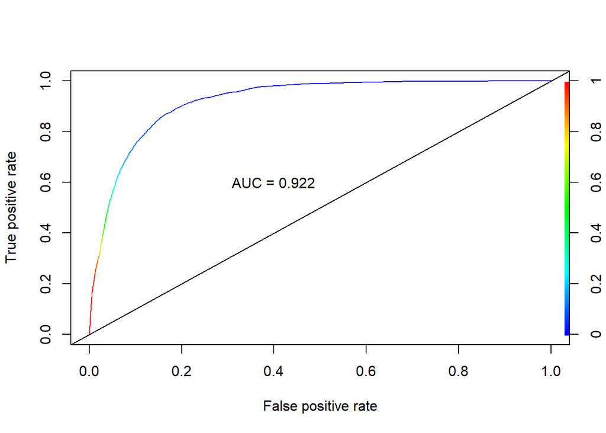

```r
#Training Set
train.lda.x <- train[ , sapply(train, is.numeric)]
train.lda.y <- train$y
fit.lda <- lda(train.lda.y ~ ., data = train.lda.x)
pred.lda <- predict(fit.lda, newdata = train.lda.x)
preds <- pred.lda$posterior
preds <- as.data.frame(preds)
pred <- prediction(preds[,2],train.lda.y)
roc.perf = performance(pred, measure = "tpr", x.measure = "fpr")
auc.train <- performance(pred, measure = "auc")
auc.train <- auc.train@y.values
plot(roc.perf, colorize = TRUE)
abline(a=0, b= 1)
text(x = .40, y = .6,paste("AUC = ", round(auc.train[[1]],3), sep = ""))
```

```r
#AUC = 0.922
```

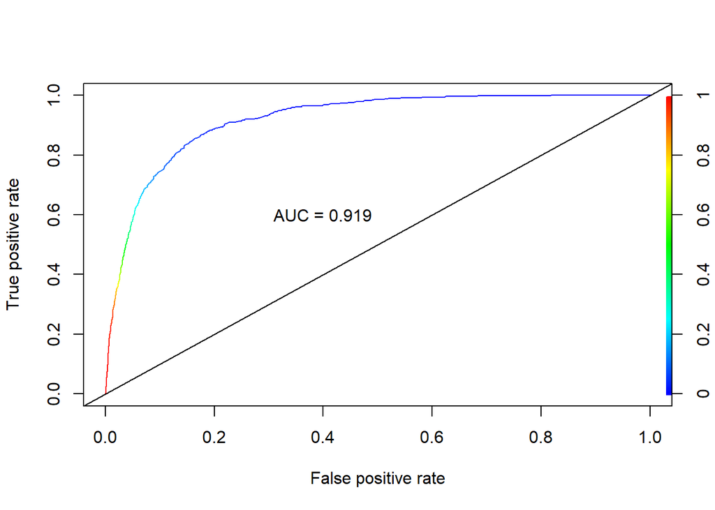

```r
# Test Set
test.lda.x <- test[ , sapply(test, is.numeric)]
test.lda.y <- test$y
pred.lda1 <- predict(fit.lda, newdata = test.lda.x)
preds1 <- pred.lda1$posterior
preds1 <- as.data.frame(preds1)
pred1 <- prediction(preds1[,2],test.lda.y)
roc.perf = performance(pred1, measure = "tpr", x.measure = "fpr")
auc.train <- performance(pred1, measure = "auc")
auc.train <- auc.train@y.values
plot(roc.perf, colorize = TRUE)
abline(a=0, b= 1)
text(x = .40, y = .6,paste("AUC = ", round(auc.train[[1]],3), sep = ""))
```

```r
#AUC = 0.919
```

Run CV loop for LDA

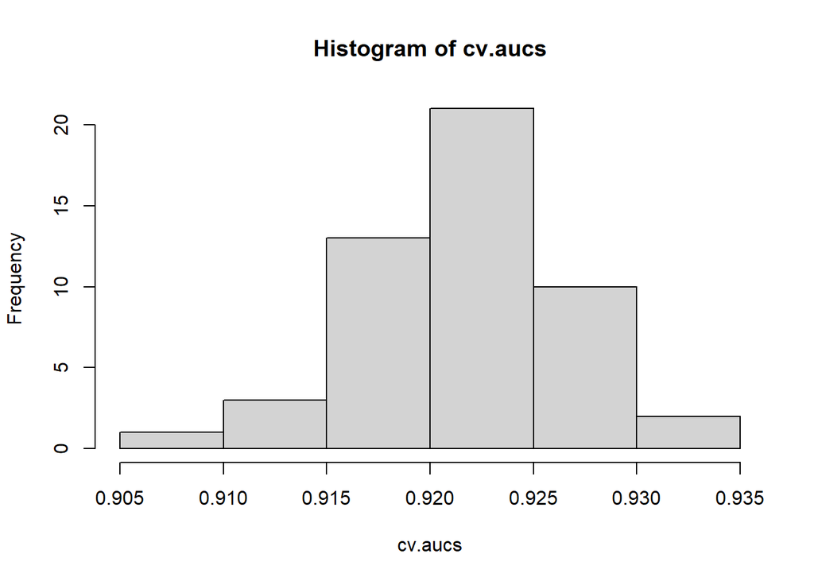

```r
#running cv on train set using LDA
nloops<-50   #number of CV loops
ntrains<-dim(train.lda.x)[1]  #No. of samples in training data set
cv.aucs<-c()

set.seed(123)
for (i in 1:nloops){
  index<-sample(1:ntrains,ntrains*.8)
  cvtrain.x<-train.lda.x[index,]
  cvtest.x<-train.lda.x[-index,]
  cvtrain.y<-train.lda.y[index]
  cvtest.y<-train.lda.y[-index]

  cvfit <- lda(cvtrain.y ~ ., data = cvtrain.x)
  fit.pred <- predict(cvfit, newdata = cvtest.x)
  preds.cv <- fit.pred$posterior
  preds.cv <- as.data.frame(preds.cv)
  pred.cv <- prediction(preds.cv[,2], cvtest.y)
  roc.perf = performance(pred.cv, measure = "tpr", x.measure = "fpr")
  auc.train <- performance(pred.cv, measure = "auc")
  auc.train <- auc.train@y.values

  cv.aucs[i]<-auc.train[[1]]
}

hist(cv.aucs)
```

```r
summary(cv.aucs)
```

```
##    Min. 1st Qu.  Median    Mean 3rd Qu.    Max.
##  0.9100  0.9187  0.9219  0.9217  0.9248  0.9336
```

```r
#   Min. 1st Qu.  Median    Mean 3rd Qu.    Max.
# 0.9100  0.9187  0.9219  0.9217  0.9248  0.9336
```

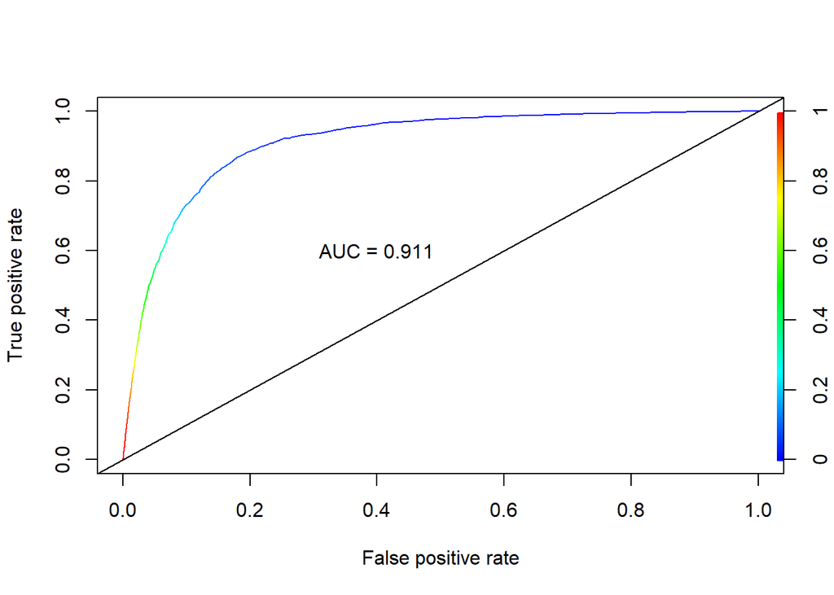

```r
#test using just the numeric ones from our best step model
fit.lda_step <- lda(train.lda.y ~ duration + campaign + previous + cons_price_idx + cons_conf_idx +  euribor3m, data = train.lda.x)
pred.lda_step <- predict(fit.lda_step, newdata = train.lda.x)
preds_step <- pred.lda_step$posterior
preds_step <- as.data.frame(preds_step)
pred_step <- prediction(preds_step[,2],train.lda.y)
roc.perf_step = performance(pred_step, measure = "tpr", x.measure = "fpr")
auc.train_step <- performance(pred_step, measure = "auc")
auc.train_step <- auc.train_step@y.values
plot(roc.perf_step, colorize = TRUE)
abline(a=0, b= 1)
text(x = .40, y = .6,paste("AUC = ", round(auc.train_step[[1]],3), sep = ""))
```

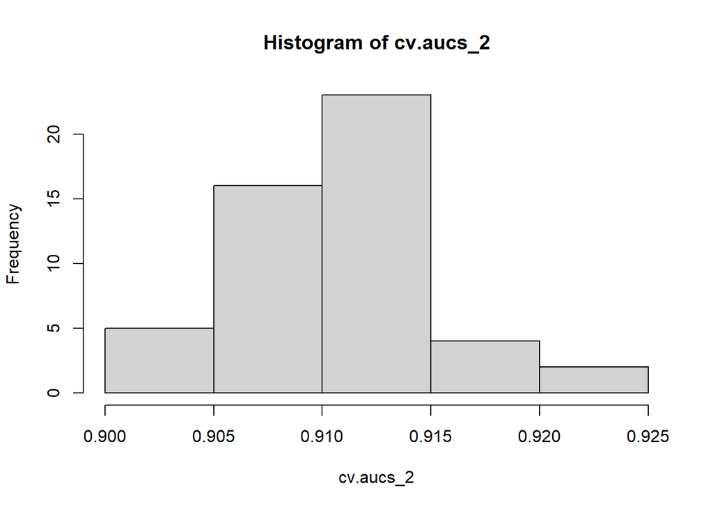

```r
#AUC = 0.911

#running cv on train set using LDA with subset of numeric vars
nloops<-50   #number of CV loops
ntrains<-dim(train.lda.x)[1]  #No. of samples in training data set
cv.aucs_2<-c()

set.seed(123)

for (i in 1:nloops) {
  index <- sample(1:ntrains, ntrains * .8)
  cvtrain.x <- train.lda.x[index, ]
  cvtest.x <- train.lda.x[-index, ]
  cvtrain.y <- train.lda.y[index]
  cvtest.y <- train.lda.y[-index]

  cvfit_2 <-
    lda(
      cvtrain.y ~ duration + campaign + previous + cons_price_idx + cons_conf_idx +  euribor3m,
      data = cvtrain.x
    )
  fit.pred_2 <- predict(cvfit_2, newdata = cvtest.x)
  preds.cv_2 <- fit.pred_2$posterior
  preds.cv_2 <- as.data.frame(preds.cv_2)
  pred.cv_2 <- prediction(preds.cv_2[, 2], cvtest.y)
  roc.perf_2 = performance(pred.cv_2, measure = "tpr", x.measure = "fpr")
  auc.train_2 <- performance(pred.cv_2, measure = "auc")
  auc.train_2 <- auc.train_2@y.values

  cv.aucs_2[i] <- auc.train_2[[1]]
}
hist(cv.aucs_2)
```

```r
summary(cv.aucs_2)
```

```
##    Min. 1st Qu.  Median    Mean 3rd Qu.    Max.
##  0.9003  0.9074  0.9114  0.9107  0.9137  0.9233
```

```r
#   Min. 1st Qu.  Median    Mean 3rd Qu.    Max.
# 0.9003  0.9074  0.9114  0.9107  0.9137  0.9233
```

The subset using the numeric vars from our step logistic model has very similar performance

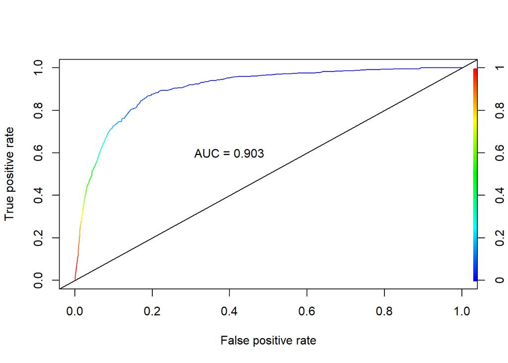

```r
#run on test set
# Test Set
pred.lda1_step <- predict(fit.lda_step, newdata = test.lda.x)
preds1_step <- pred.lda1_step$posterior
preds1_step <- as.data.frame(preds1_step)
pred1_step <- prediction(preds1_step[, 2], test.lda.y)
roc.perf_step2 = performance(pred1_step, measure = "tpr", x.measure = "fpr")
auc.train_step2 <- performance(pred1_step, measure = "auc")
auc.train_step2 <- auc.train_step2@y.values
plot(roc.perf_step2, colorize = TRUE)
abline(a = 0, b = 1)
text(x = .40, y = .6, paste("AUC = ", round(auc.train_step2[[1]], 3), sep = ""))
```

```r
#AUC = 0.903
```

Run once more, but just the numeric from above, removing those that act more like factors.

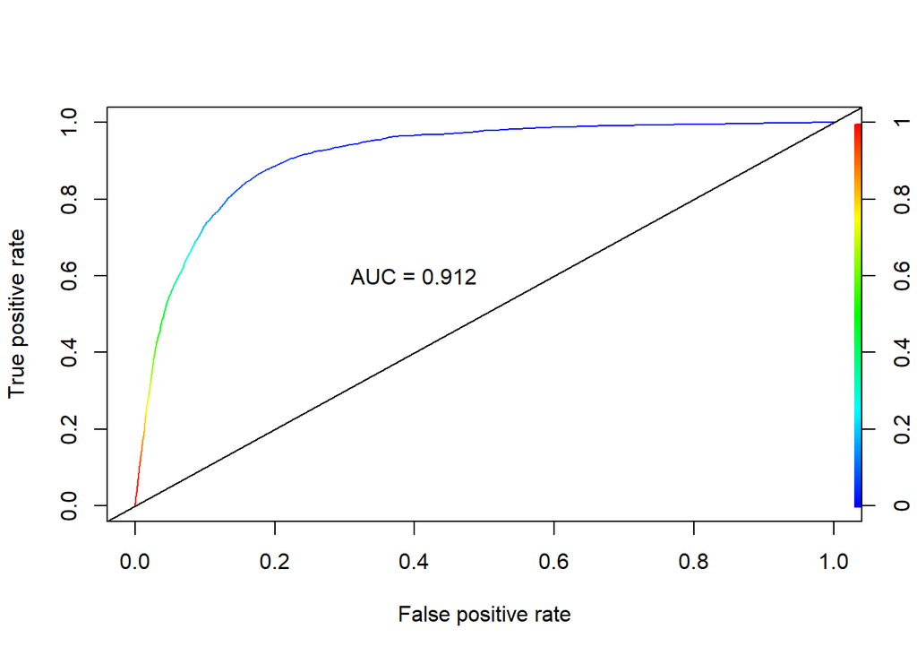

```r
#test using just the numeric ones from our best step model
fit.lda_step2 <-
  lda(train.lda.y ~ duration  + cons_price_idx + cons_conf_idx +  euribor3m,
      data = train.lda.x)
pred.lda_step2 <- predict(fit.lda_step2, newdata = train.lda.x)
preds_step2 <- pred.lda_step2$posterior
preds_step2 <- as.data.frame(preds_step2)
pred_step2 <- prediction(preds_step2[, 2], train.lda.y)
roc.perf_step2 = performance(pred_step2, measure = "tpr", x.measure = "fpr")
auc.train_step2 <- performance(pred_step2, measure = "auc")
auc.train_step2 <- auc.train_step2@y.values
plot(roc.perf_step2, colorize = TRUE)
abline(a = 0, b = 1)
text(x = .40, y = .6, paste("AUC = ", round(auc.train_step2[[1]], 3), sep = ""))
```

```r
#AUC = 0.912
```

No significant change.

### Running QDA

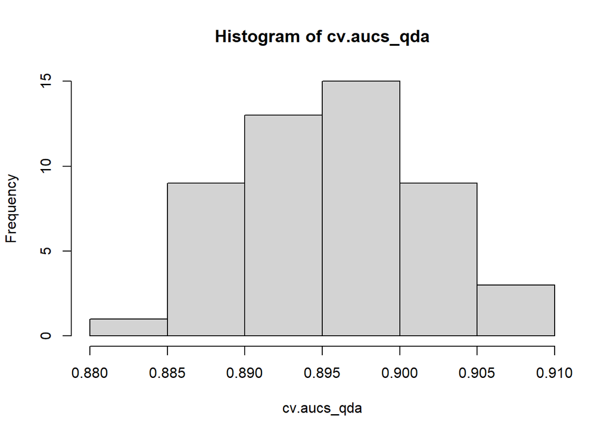

```r
#running cv on train set using QDA with subset of numeric vars
nloops<-50   #number of CV loops
ntrains<-dim(train.lda.x)[1]  #No. of samples in training data set
cv.aucs_qda<-c()

set.seed(123)

for (i in 1:nloops) {
  index <- sample(1:ntrains, ntrains * .8)
  cvtrain.x <- train.lda.x[index, ]
  cvtest.x <- train.lda.x[-index, ]
  cvtrain.y <- train.lda.y[index]
  cvtest.y <- train.lda.y[-index]

  cvfit_qda <-
    qda(
      cvtrain.y ~ duration + campaign + previous + cons_price_idx + cons_conf_idx +  euribor3m,
      data = cvtrain.x
    )
  fit.pred_qda <- predict(cvfit_qda, newdata = cvtest.x)
  preds.cv_qda <- fit.pred_qda$posterior
  preds.cv_qda <- as.data.frame(preds.cv_qda)
  pred.cv_qda <- prediction(preds.cv_qda[, 2], cvtest.y)
  roc.perf_qda = performance(pred.cv_qda, measure = "tpr", x.measure = "fpr")
  auc.train_qda <- performance(pred.cv_qda, measure = "auc")
  auc.train_qda <- auc.train_qda@y.values

  cv.aucs_qda[i] <- auc.train_qda[[1]]
}

hist(cv.aucs_qda)
```

```r
summary(cv.aucs_qda)
```

```
##    Min. 1st Qu.  Median    Mean 3rd Qu.    Max.
##  0.8845  0.8911  0.8958  0.8955  0.8993  0.9097
```

```r
#   Min. 1st Qu.  Median    Mean 3rd Qu.    Max.
# 0.8845  0.8911  0.8958  0.8955  0.8993  0.9097
```

### QDA on train set

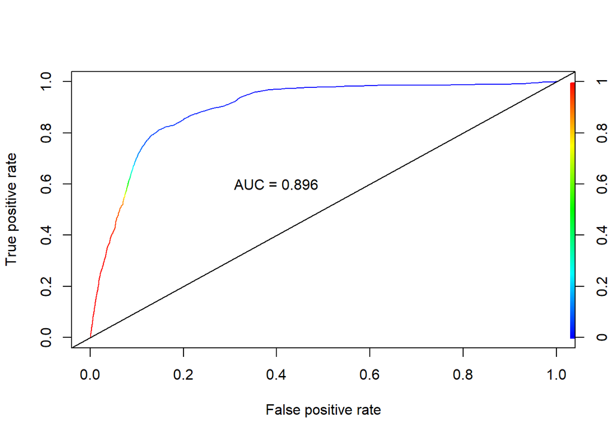

```r
fit.qda <-
  qda(
    train.lda.y ~ duration + campaign + previous + cons_price_idx + cons_conf_idx +  euribor3m,
    data = train.lda.x
  )

pred.qda <- predict(fit.qda, newdata = train.lda.x)
preds_qda <- pred.qda$posterior
preds_qda <- as.data.frame(preds_qda)
pred_qda <- prediction(preds_qda[, 2], train.lda.y)
roc.perf_qda = performance(pred_qda, measure = "tpr", x.measure = "fpr")
auc.train_qda <- performance(pred_qda, measure = "auc")
auc.train_qda <- auc.train_qda@y.values
plot(roc.perf_qda, colorize = TRUE)
abline(a = 0, b = 1)
text(x = .40, y = .6, paste("AUC = ", round(auc.train_qda[[1]], 3), sep = ""))
```

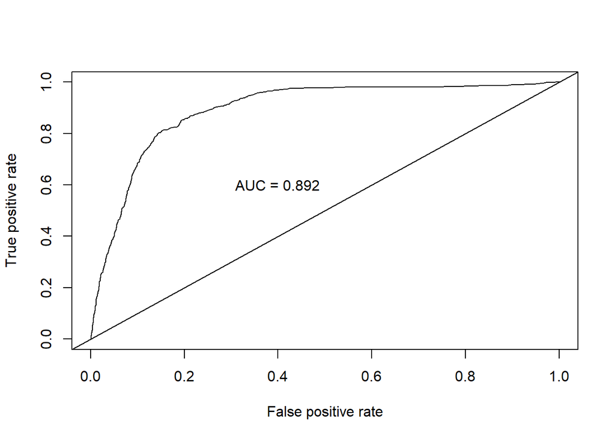

```r
#AUC = 0.896

# Test Set
pred.qda1 <- predict(fit.qda, newdata = test.lda.x)
preds1_qda <- pred.qda1$posterior
preds1_qda <- as.data.frame(preds1_qda)
pred1_qda <- prediction(preds1_qda[, 2], test.lda.y)
roc.perf_qda1 = performance(pred1_qda, measure = "tpr", x.measure = "fpr")
auc.train_qda1 <- performance(pred1_qda, measure = "auc")
auc.train_qda1 <- auc.train_qda1@y.values
plot(roc.perf_qda1)
abline(a = 0, b = 1)
text(x = .40, y = .6, paste("AUC = ", round(auc.train_qda1[[1]], 3), sep = ""))
```

```r
#AUC = 0.892
```

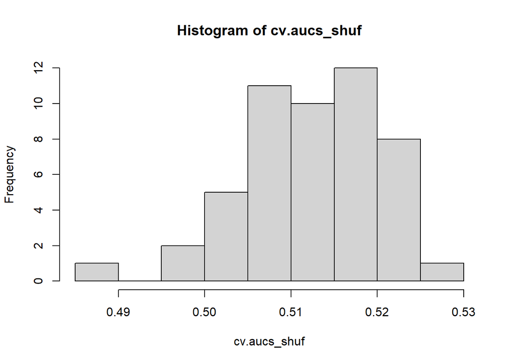

```r
#Run randomly shuffled y -vars because the models are performing very similarly
nloops<-50   #number of CV loops
ntrains<-dim(train.lda.x)[1]  #No. of samples in training data set
cv.aucs_shuf<-c()
dat.train.yshuf<-train.lda.y[sample(1:length(train.lda.y))]

set.seed(123)

for (i in 1:nloops) {
  index <- sample(1:ntrains, ntrains * .8)
  cvtrain.x <- train.lda.x[index, ]
  cvtest.x <- train.lda.x[-index, ]
  cvtrain.yshuf <- dat.train.yshuf[index]
  cvtest.yshuf <- dat.train.yshuf[-index]

  cvfit_shuf <-
    lda(
      cvtrain.yshuf ~ duration + campaign + previous + cons_price_idx + cons_conf_idx +  euribor3m,
      data = cvtrain.x
    )
  fit.pred_shuf <- predict(cvfit_shuf, newdata = cvtest.x)
  preds.cv_shuf <- fit.pred_shuf$posterior
  preds.cv_shuf <- as.data.frame(preds.cv_shuf)
  pred.cv_shuf <- prediction(preds.cv_shuf[, 2], cvtest.yshuf)
  roc.perf_shuf = performance(pred.cv_shuf, measure = "tpr", x.measure = "fpr")
  auc.train_shuf <- performance(pred.cv_shuf, measure = "auc")
  auc.train_shuf <- auc.train_shuf@y.values

  cv.aucs_shuf[i] <- auc.train_shuf[[1]]
}
hist(cv.aucs_shuf)
```

```r
summary(cv.aucs_shuf)
```

```
##    Min. 1st Qu.  Median    Mean 3rd Qu.    Max.
##  0.4871  0.5081  0.5127  0.5125  0.5186  0.5299
```

```r
 #  Min. 1st Qu.  Median    Mean 3rd Qu.    Max.
 #0.4871  0.5081  0.5127  0.5125  0.5186  0.5299
```

The AUC degrades to ~0.5 so we seem to be doing something right.

Generate confusion matrix and accuracy/sens/spec for best LDA model with matching vars to logistic model

From our ROC curve, the best cut-off looks to be between 0.1 and 0.2

```r
cutoff<-0.15
class.lda_all<-factor(ifelse(preds1[2]>cutoff,"yes","no"),levels=c("no","yes"))
class.lda_step<-factor(ifelse(preds1_step[2]>cutoff,"yes","no"),levels=c("no","yes"))
class.qda_step<-factor(ifelse(preds1_qda[2]>cutoff,"yes","no"),levels=c("no","yes"))
```

## Confusion matrices

```r
#Confusion Matrix for LDA with all vars
conf.lda_all<-table(class.lda_all,test.lda.y)
print("Confusion matrix for LDA with all Vars")
```

```
## [1] "Confusion matrix for LDA with all Vars"
```

```r
conf.lda_all
```

```
##              test.lda.y
## class.lda_all   no  yes
##           no  6213  241
##           yes  584  611
```

```r
#Confusion Matrix for LDA with stepwise vars
conf.lda_step<-table(class.lda_step,test.lda.y)
print("Confusion matrix for LDA with some Vars")
```

```
## [1] "Confusion matrix for LDA with some Vars"
```

```r
conf.lda_step
```

```
##               test.lda.y
## class.lda_step   no  yes
##            no  6053  223
##            yes  744  629
```

```r
#Confusion Matrix for QDA with stepwise vars
conf.qda_step<-table(class.qda_step,test.lda.y)
print("Confusion matrix for QDA with some Vars")
```

```
## [1] "Confusion matrix for QDA with some Vars"
```

```r
conf.qda_step
```

```
##               test.lda.y
## class.qda_step   no  yes
##            no  6065  246
##            yes  732  606
```

```r
#Accuracy of LASSO and Stepwise
print("Overall accuracy for LDA w/ all vars, LDA w/ some vars, and QDA respectively")
```

```
## [1] "Overall accuracy for LDA w/ all vars, LDA w/ some vars, and QDA respectively"
```

```r
sum(diag(conf.lda_all))/sum(conf.lda_all)
```

```
## [1] 0.8921428
```

```r
sum(diag(conf.lda_all))/sum(conf.lda_all)
```

[output not shown]

```r
sum(diag(conf.qda_step))/sum(conf.qda_step)
```

```
## [1] 0.8721401
```

```r
#Confusion Matrix for cut off =0.15
lda_all_0.15<-confusionMatrix(conf.lda_all)
lda_step_0.15<-confusionMatrix(conf.lda_step)
qda_0.15<-confusionMatrix(conf.qda_step)
lda_all_0.15
```

```
## Confusion Matrix and Statistics
##
##              test.lda.y
## class.lda_all   no  yes
##           no  6213  241
##           yes  584  611
##
##                Accuracy : 0.8921
##                  95% CI : (0.885, 0.899)
##     No Information Rate : 0.8886
##     P-Value [Acc > NIR] : 0.1678
##
##                   Kappa : 0.5367
##
##  Mcnemar's Test P-Value : <2e-16
##
##             Sensitivity : 0.9141
##             Specificity : 0.7171
##          Pos Pred Value : 0.9627
##          Neg Pred Value : 0.5113
##              Prevalence : 0.8886
##          Detection Rate : 0.8123
##    Detection Prevalence : 0.8438
##       Balanced Accuracy : 0.8156
##
##        'Positive' Class : no
##
```

```r
lda_step_0.15
```

```
## Confusion Matrix and Statistics
##
##               test.lda.y
## class.lda_step   no  yes
##            no  6053  223
##            yes  744  629
##
##                Accuracy : 0.8736
##                  95% CI : (0.8659, 0.8809)
##     No Information Rate : 0.8886
##     P-Value [Acc > NIR] : 1
##
##                   Kappa : 0.4961
##
##  Mcnemar's Test P-Value : <2e-16
##
##             Sensitivity : 0.8905
##             Specificity : 0.7383
##          Pos Pred Value : 0.9645
##          Neg Pred Value : 0.4581
##              Prevalence : 0.8886
##          Detection Rate : 0.7913
##    Detection Prevalence : 0.8205
##       Balanced Accuracy : 0.8144
##
##        'Positive' Class : no
##
```

```r
qda_0.15
```

```
## Confusion Matrix and Statistics
##
##               test.lda.y
## class.qda_step   no  yes
##            no  6065  246
##            yes  732  606
##
##                Accuracy : 0.8721
##                  95% CI : (0.8644, 0.8795)
##     No Information Rate : 0.8886
##     P-Value [Acc > NIR] : 1
##
##                   Kappa : 0.4831
##
##  Mcnemar's Test P-Value : <2e-16
##
##             Sensitivity : 0.8923
##             Specificity : 0.7113
##          Pos Pred Value : 0.9610
##          Neg Pred Value : 0.4529
##              Prevalence : 0.8886
##          Detection Rate : 0.7929
##    Detection Prevalence : 0.8251
##       Balanced Accuracy : 0.8018
##
##        'Positive' Class : no
##
```

```r
Sensitivity_LDA <-
  data.frame(
    "Model" = c("LDA All", "LDA Stepwise", "QDA Stepwise"),
    "Sensitivity" = c(
      lda_all_0.15$byClass[1],
      lda_step_0.15$byClass[1],
      qda_0.15$byClass[1]
    )
  )
Specificity_LDA <-
  data.frame("Specificity" = c(
    lda_all_0.15$byClass[2],
    lda_step_0.15$byClass[2],
    qda_0.15$byClass[2]
  ))
Accuracy_LDA <-
  data.frame("Accuracy" = c(
    lda_all_0.15$overall[1],
    lda_step_0.15$overall[1],
    qda_0.15$overall[1]
  ))

Overall <- cbind(Sensitivity_LDA, Specificity_LDA, Accuracy_LDA)
Overall
```

```
##          Model Sensitivity Specificity  Accuracy
## 1      LDA All   0.9140797   0.7171362 0.8921428
## 2 LDA Stepwise   0.8905399   0.7382629 0.8735782
## 3 QDA Stepwise   0.8923054   0.7112676 0.8721401
```

# Random Forest

## Load the data

```r
#train <- read.csv("../data/train.csv", stringsAsFactors = TRUE)
#test <- read.csv("../data/test.csv", stringsAsFactors = TRUE)
# set up train2/test2 to explore modeling without duration
#train2 <- train %>% dplyr::select(c(-duration, -duration_group))
#test2 <- test %>% dplyr::select(c(-duration, -duration_group))
#train_orig <- train
#test_orig <- test
#train <- train2
#test <- test2
```

## Train a Random Forest, tuning mtry and splitrule

```r
set.seed(1234)
cv_control <- trainControl(method="cv",
                     classProbs = TRUE,
                     savePredictions = TRUE,
                     summaryFunction = twoClassSummary,
                     num = 5)
rf_grid <- expand.grid(
  mtry = 4:8,
  splitrule = c("gini","extratrees", "hellinger"),
  min.node.size = c(1)
)
fitRF <- train(y ~ .,
               data = train,
               method = "ranger",
               metric = "ROC",
               importance = "impurity",
               trControl = cv_control,
               num.threads = 6,
               num.trees = 30,
               tuneGrid=rf_grid)
fitRF
```

```
## Random Forest
##
## 30593 samples
##    23 predictor
##     2 classes: 'no', 'yes'
##
## No pre-processing
## Resampling: Cross-Validated (5 fold)
## Summary of sample sizes: 24473, 24475, 24474, 24475, 24475
## Resampling results across tuning parameters:
##
##   mtry  splitrule   ROC        Sens       Spec
##   4     gini        0.9366184  0.9707947  0.4189638
##   4     extratrees  0.9309623  0.9773053  0.3355838
##   4     hellinger   0.9386809  0.9741420  0.3922432
##   5     gini        0.9381864  0.9673373  0.4609484
##   5     extratrees  0.9310408  0.9707580  0.3943076
##   5     hellinger   0.9387271  0.9676314  0.4509670
##   6     gini        0.9379654  0.9643211  0.4882470
##   6     extratrees  0.9307549  0.9675211  0.4233730
##   6     hellinger   0.9390297  0.9653879  0.4765129
##   7     gini        0.9371883  0.9624085  0.4952980
##   7     extratrees  0.9295099  0.9644314  0.4362883
##   7     hellinger   0.9393942  0.9634751  0.4870795
##   8     gini        0.9377880  0.9627763  0.4908953
##   8     extratrees  0.9308877  0.9628130  0.4577174
##   8     hellinger   0.9384500  0.9632176  0.4985324
##
## Tuning parameter 'min.node.size' was held constant at a value of 1
## ROC was used to select the optimal model using the largest value.
## The final values used for the model were mtry = 7, splitrule = hellinger
##  and min.node.size = 1.
```

I chose to tune 2 hyper parameters for Random Forest 1. mtry which represents the number of predictors considered when splitting a node in a tree 2. splitrule which determines the rule used for the actual splitting based on the above predictors Note: I set min.node.size to 1 as appropriate for classification

## Performance on Training Set

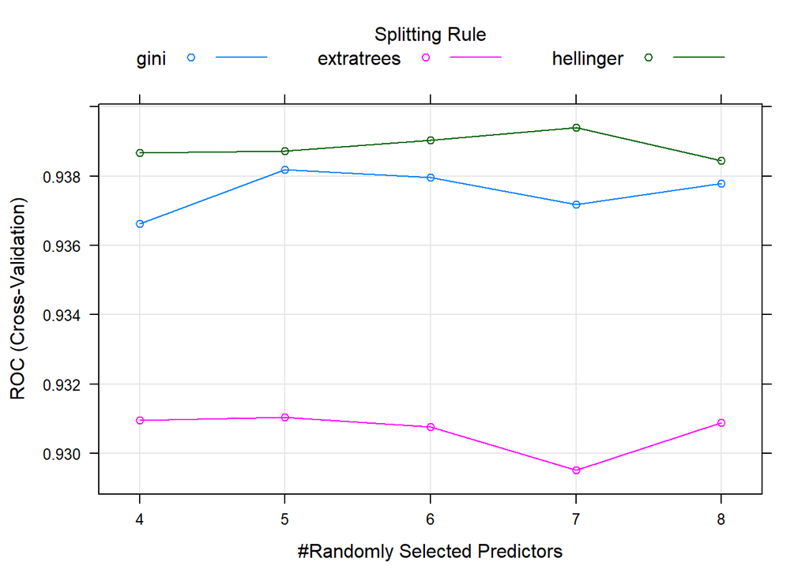

```r
plot(fitRF)
```

```r
confusionMatrix(fitRF, positive = "yes")
```

```
## Cross-Validated (5 fold) Confusion Matrix
##
## (entries are percentual average cell counts across resamples)
##
##           Reference
## Prediction   no  yes
##        no  85.6  5.7
##        yes  3.2  5.4
##
##  Accuracy (average) : 0.9104
```

### Min Depth Distribution

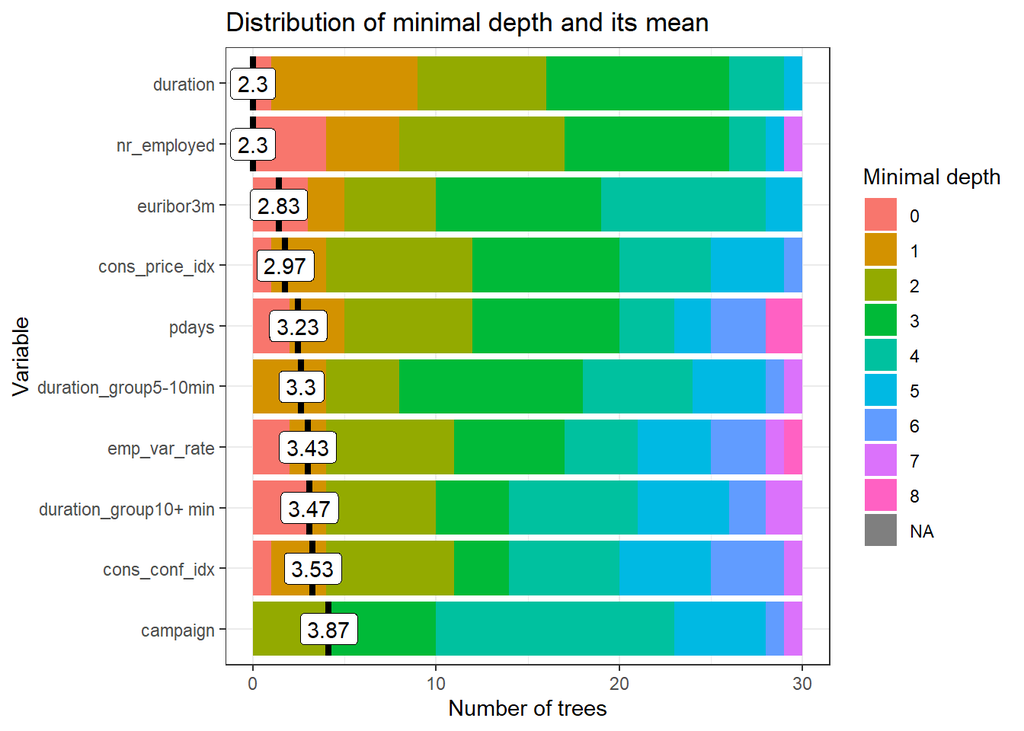

```r
library(randomForestExplainer)
forest_frame <- min_depth_distribution(fitRF$finalModel)
plot_min_depth_distribution(forest_frame)
```

# Other measures of importance

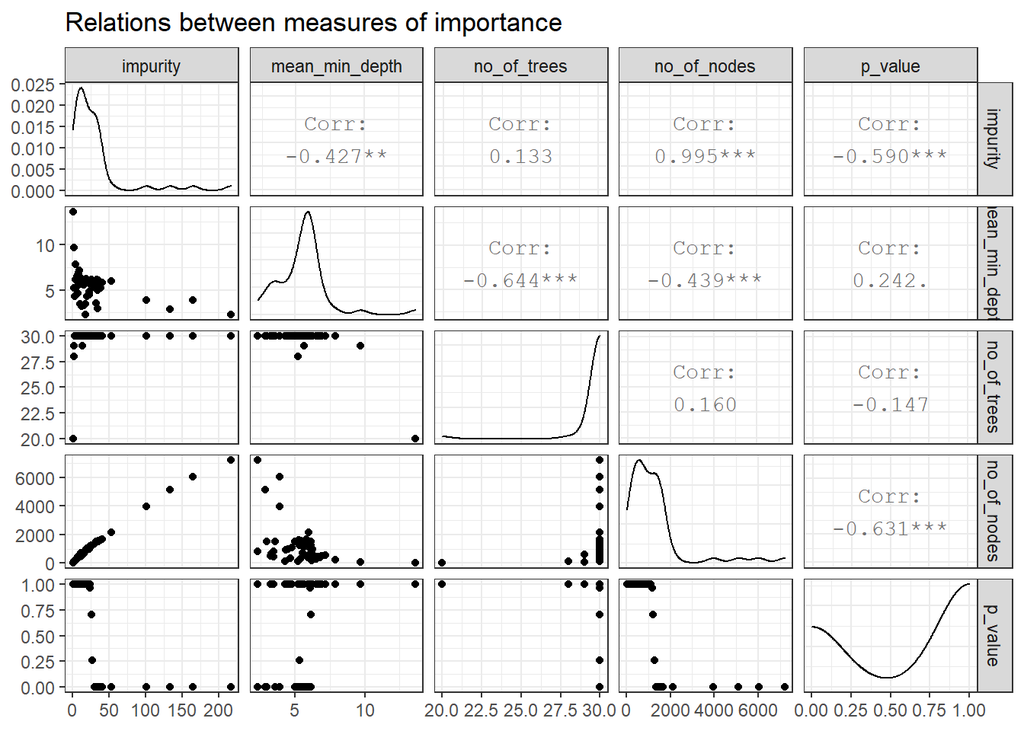

## Performance on Test Set

```r
fitRF.predictions.raw <- predict(fitRF, newdata = test, type="raw")
fitRF.predictions.prob <- predict(fitRF, newdata = test, type="prob")
confusionMatrix(fitRF.predictions.raw, test$y, positive = "yes")
```

```
## Confusion Matrix and Statistics
##
##           Reference
## Prediction   no  yes
##        no  6561  408
##        yes  236  444
##
##                Accuracy : 0.9158
##                  95% CI : (0.9094, 0.9219)
##     No Information Rate : 0.8886
##     P-Value [Acc > NIR] : 2.308e-15
##
##                   Kappa : 0.5335
##
##  Mcnemar's Test P-Value : 1.602e-11
##
##             Sensitivity : 0.52113
##             Specificity : 0.96528
##          Pos Pred Value : 0.65294
##          Neg Pred Value : 0.94146
##              Prevalence : 0.11139
##          Detection Rate : 0.05805
##    Detection Prevalence : 0.08890
##       Balanced Accuracy : 0.74320
##
##        'Positive' Class : yes
##
```

Using the default cutoff, our random forest gets a test accuracy of 0.9158, with Sensitivity 0.52113 and Specificity 0.96528.

# ROC Curve and Optimal Cutoff

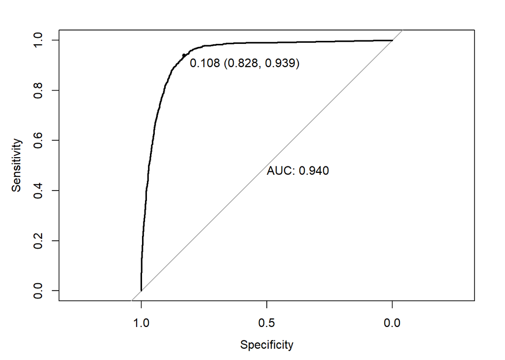

```r
prediction.probabilities <- fitRF.predictions.prob$yes
predicted.classes <- fitRF.predictions.raw
observed.classes <- test$y

# Compute roc
res.roc <- roc(observed.classes, prediction.probabilities)
plot.roc(res.roc, print.auc = TRUE, print.thres = "best")
```

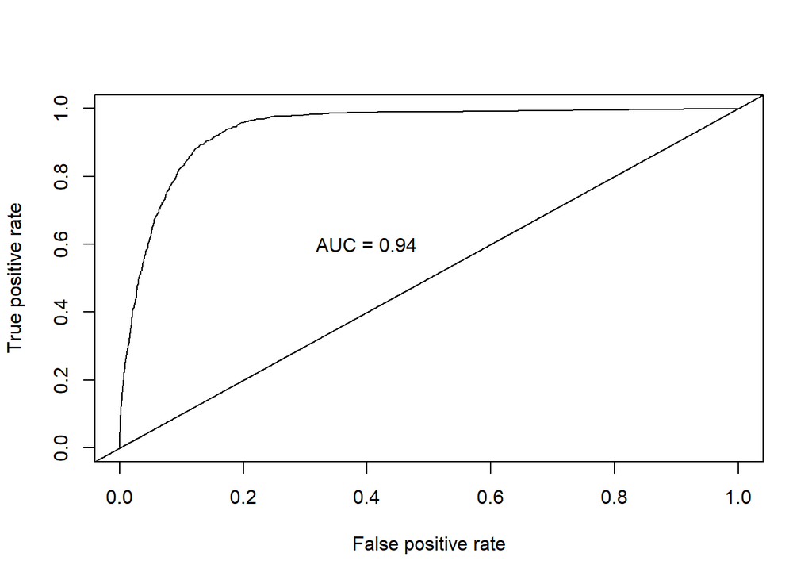

```r
# If we wanted cutoffs for specific specificities we specifically specify, we could do THIS:
#roc.data <- data_frame(
#  thresholds = res.roc$thresholds,
#  sensitivity = res.roc$sensitivities,
#  specificity = res.roc$specificities
#)
# Then we can get the cutoff for specificity = <something> like this
#roc.data %>% filter(specificity >= 0.6)
#...or similar

#ROCR - trying to get in same format for overlay below
pred.rf <- prediction(fitRF.predictions.prob[,2],test$y)
roc.perf_rf = performance(pred.rf, measure = "tpr", x.measure = "fpr")
auc.rf <- performance(pred.rf, measure = "auc")
auc.rf <- auc.rf@y.values
plot(roc.perf_rf)
abline(a=0, b= 1)
text(x = .40, y = .6,paste("AUC = ", round(auc.rf[[1]],3), sep = ""))
```

The most balanced cutoff for this model is 0.108

## ROC Curve and Optimal Cutoff

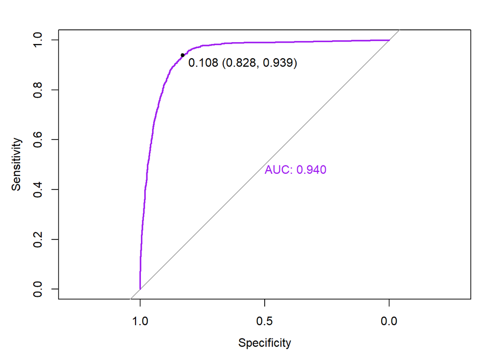

```r
library(pROC)
prediction.probabilities <- fitRF.predictions.prob$yes
predicted.classes <- fitRF.predictions.raw
observed.classes <- test$y

# Compute roc
roc.randomforest <- roc(observed.classes, prediction.probabilities)
plot.roc(roc.randomforest, print.auc = TRUE, print.thres = "best", col="purple")
```

```r
# Get the best cutoff for balancing Sensitivity and Specificity
cutoff <- coords(roc.randomforest, "best", ret="threshold", transpose = FALSE)$threshold

# Predict using the best cutoff and confirm with a Confusion Matrix
predicted.classes.balanced <- factor(
  ifelse( fitRF.predictions.prob$yes > cutoff, "yes", "no"), levels=c("no","yes"))
confusionMatrix(predicted.classes.balanced, test$y, positive="yes")
```

```
## Confusion Matrix and Statistics
##
##           Reference
## Prediction   no  yes
##        no  5631   52
##        yes 1166  800
##
##                Accuracy : 0.8408
##                  95% CI : (0.8324, 0.8489)
##     No Information Rate : 0.8886
##     P-Value [Acc > NIR] : 1
##
##                   Kappa : 0.4882
##
##  Mcnemar's Test P-Value : <2e-16
##
##             Sensitivity : 0.9390
##             Specificity : 0.8285
##          Pos Pred Value : 0.4069
##          Neg Pred Value : 0.9908
##              Prevalence : 0.1114
##          Detection Rate : 0.1046
##    Detection Prevalence : 0.2570
##       Balanced Accuracy : 0.8837
##
##        'Positive' Class : yes
##
```

```r
# If exploring modeling without duration, restore the original train/test for use by any code below that might rely on it
#train <- train_orig
#test <- test_orig
```

# Model Comparison

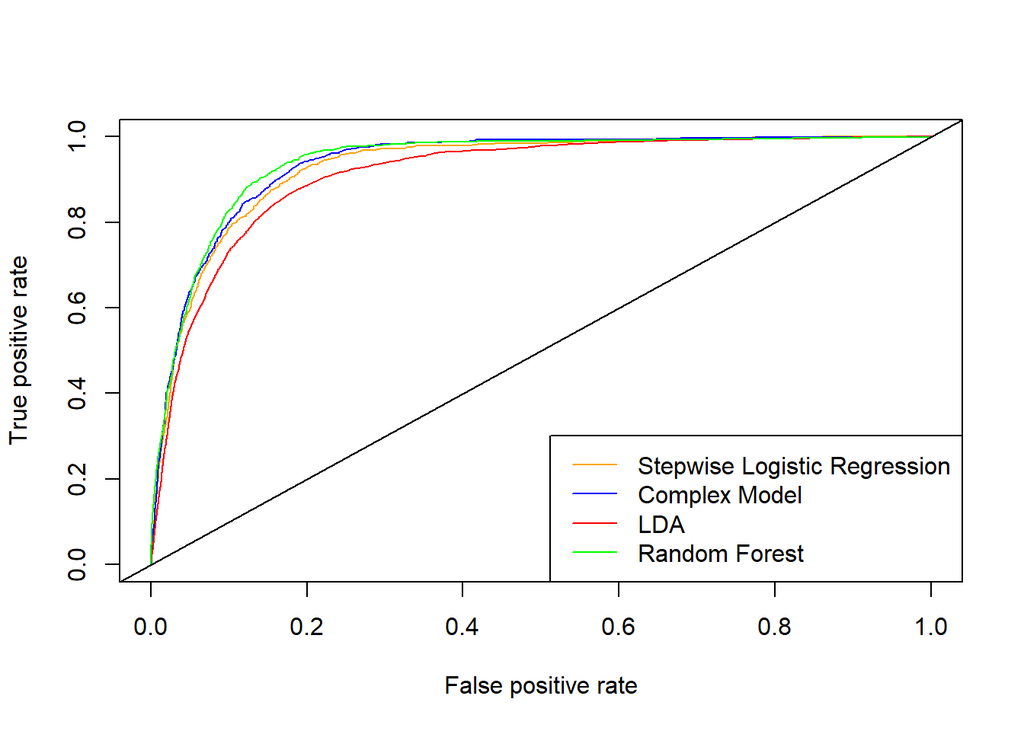

```r
#graphics.off()

#add ROC curve for our top simple model, complex model, LDA, and RF
plot(roc.step,col="orange")
plot(roc.complex,col = "blue", add = TRUE)
plot(roc.perf_step2, col="red", add = TRUE)
plot(roc.perf_rf, col = "green", add = TRUE)
legend("bottomright",legend=c("Stepwise Logistic Regression","Complex Model", "LDA", "Random Forest"),col=c("orange","blue","red","green"),lty=1,lwd=1)
abline(a=0, b= 1)
```

## R Code

```r
knitr::opts_chunk$set(echo = TRUE)
#load libraries
library(dplyr)
library(tidyverse)
library(ggplot2)
library(caret)
library(e1071)
library(class)
library(gridExtra)
library(summarytools)
library(gt)
library(corrplot)
library(janitor)
library(tidyselect)
library(GGally)
library(randomForest)
library(car)
library(ROCR)
library(MASS)
library(glmnet)
library(pROC)
library(pacman)
library(ranger)
library(randomForestExplainer)
library(broom)
#full <- read_delim(here::here("data", "bank-additional-full.csv"),';')
full <- read.csv(file.choose(), sep=';')
str(full)
head(full)
nrow(full)
ncol(full)

# Clean up column names
full <- janitor::clean_names(full)
summary(full)

#print(dfSummary(full, graph.magnif = 0.75), method = 'browser')
str(full)

# Check for missing values
tibble(variable = names(colSums(is.na(full))),
       missing = colSums(is.na(full))) %>%
  gt() %>%
  tab_header(title = "Missing Values in Data")
#remove "unknowns" based on small sample sizes compared to full data set
df <- full %>%  filter(loan != "unknown")
nrow(df)
#down to 40,198 obs
df <- df %>%  filter(marital != "unknown")
nrow(df)
#down to 40,119 obs
df <- df %>%  filter(education != "unknown")
nrow(df)
#down to 38,437 obs
#remove unknowns from job
df <- df %>%  filter(job != "unknown")
nrow(df)
#down to 38,245 obs
#remove yes from default - only 3, and all 3 are "no"
df <- df %>%  filter(default != "yes")
nrow(df)
#down to 38,242 obs
str(df)
#recheck summary
summary(df)
summary(df)
#change some variables to factor
cols <- c("job", "marital", "education", "housing","loan","contact","month","day_of_week","default","poutcome","y")
df[cols] <- lapply(df[cols], factor)
str(df)

#make sure "success" level is defined as "yes"
str(df$y)
#run first pass PCA to see if we have useful numeric predictors
df.numeric <- df[ , sapply(df, is.numeric)]
pc.result<-prcomp(df.numeric,scale.=TRUE)
pc.scores<-pc.result$x
pc.scores<-data.frame(pc.scores)
pc.scores$y<-df$y

#pc.scores

#Scree plot
eigenvals<-(pc.result$sdev)^2
eigenvals
plot(1:10,eigenvals/sum(eigenvals),type="l",main="Scree Plot PC's",ylab="Prop. Var. Explained",ylim=c(0,1))
cumulative.prop<-cumsum(eigenvals/sum(eigenvals))
lines(1:10,cumulative.prop,lty=2)

#Use ggplot2 to plot the first few pc's
ggplot(data = pc.scores, aes(x = PC1, y = PC2)) +
  geom_point(aes(col=y), size=1)+
  ggtitle("PCA of Numeric Data pre-EDA")

#There is some separation, but it is not in a way we would hope for our response variable
ggplot(data = pc.scores, aes(x = PC2, y = PC3)) +
  geom_point(aes(col=y), size=1)+
  ggtitle("PCA of Numeric Data pre-EDA")
ggplot(data = pc.scores, aes(x = PC3, y = PC4)) +
  geom_point(aes(col=y), size=1)+
  ggtitle("PCA of Numeric Data pre-EDA")
df.numeric2 <- df.numeric %>% dplyr::select(-c(pdays, campaign, previous))
pc.result2<-prcomp(df.numeric2,scale.=TRUE)
pc.scores2<-pc.result2$x
pc.scores2<-data.frame(pc.scores2)
pc.scores2$y<-df$y
#pc.scores2

#Scree plot
eigenvals2<-(pc.result2$sdev)^2
eigenvals2
plot(1:7,eigenvals2/sum(eigenvals2),type="l",main="Scree Plot PC's",ylab="Prop. Var. Explained",ylim=c(0,1))
cumulative.prop2<-cumsum(eigenvals2/sum(eigenvals2))
lines(1:7,cumulative.prop2,lty=2)

#Use ggplot2 to plot the first few pc's
ggplot(data = pc.scores2, aes(x = PC1, y = PC2)) +
  geom_point(aes(col=y), size=1)+
  ggtitle("PCA of Numeric Data pre-EDA")

#There is some separation, but it is not in a way we would hope for our response variable
ggplot(data = pc.scores2, aes(x = PC2, y = PC3)) +
  geom_point(aes(col=y), size=1)+
  ggtitle("PCA of Numeric Data pre-EDA")

ggplot(data = pc.scores2, aes(x = PC3, y = PC4)) +
  geom_point(aes(col=y), size=1)+
  ggtitle("PCA of Numeric Data pre-EDA")
#ggpairs(df,columns=1:18, aes(colour=y))
ggpairs(df,columns=2:7, aes(colour=y))
ggpairs(df, columns=14:18, aes(colour=y))
df_yes <- df %>%   filter(y=="yes")

#summary(df_yes)
# Nothing interesting found in the below code so commenting it out
# ggplot(bank_additional_full, aes(x=age, y=emp.var.rate)) +
#   geom_point(size=1, shape="circle") +
#   ggtitle("Employment Variation Rate vs Age") +
#   facet_wrap(~ y)

ggplot(df, aes(x=age, y=duration, color = y)) +  geom_point(size=1, shape="circle") +   ggtitle("Duration vs Age")
ggplot(df, aes(x = age, y = cons_price_idx, color = y)) +
  geom_point(size = 1, shape = "circle") +
  ggtitle("Consumer Price Index vs Age")

#Checking collinearlity using box plots
ggplot(df, aes(x = age, y = cons_price_idx, fill = y)) +
  geom_boxplot() +
  ggtitle("Consumer Price Index vs Age")

ggplot(df, aes(x = duration , y = age, fill = y)) +
  geom_boxplot() +   ggtitle("Age vs. duration")

ggplot(df, aes(x = cons_price_idx , y = cons_conf_idx, fill = y)) +
  geom_boxplot() +
  ggtitle("cons.price.idx vs. cons.conf.idx")

ggplot(df, aes(x = cons_price_idx , y = emp_var_rate, fill = y)) +
  geom_boxplot() +
  ggtitle("cons.price.idx vs. emp.var.rate")

ggplot(df) + geom_histogram(mapping = aes(x = nr_employed, fill = y)) +
  ggtitle("Distribution of 'y' by nr.employed")

# ggplot(bank_additional_full, aes(x=age, y=education)) +
#   geom_point(size=1, shape="circle") +
#   ggtitle("Education vs Age")  +
#    facet_wrap(~ y)
ggplot(df)+
  geom_histogram(mapping = aes(x = age, fill = y)) +
  ggtitle("Distribution of 'y' by age")
#Age_Grp - split the data into age groups "17-31","32-37" ,"38-47", "47-55", ">55" (based in IQR)
df$Age_Grp <- cut(df$age, breaks = c(16,31,37,46,55,98), labels = c("17-31","32-37" ,"38-47", "47-55", ">55"))

#validate the cut command
#df %>% filter(!$Age_Grp  %in% c("17-31","32-37" ,"38-47", "47-55", ">55"))
#df %>% filter(df$age==55)

ggplot(df) +
  geom_bar(mapping = aes(x=Age_Grp, fill = y)) +
  ggtitle("Distribution of 'y' by Age_Grp") +
  ylab("Cnt") +
  xlab("Age Group")
ggplot(df) +
  geom_histogram(mapping = aes(x=pdays, fill=y))
#zoom in for ones that were previously contacted
df %>%
  filter(pdays < 999) %>%
  ggplot() +
  geom_histogram(mapping = aes(x=pdays, fill=y))
df$prevly_Cntctd <- as.factor(case_when(df$pdays==999 ~ "No", !df$pdays==999 ~ "Yes"))
```

```r
#Validate previously contacted variable

#df %>% filter(!df$pdays==999)

ggplot(df) +
  geom_bar(mapping = aes(x=prevly_Cntctd, fill = y)) +
  ggtitle("Number of 'y' by whether customers were prev.contacted or not") +
  ylab("Cnt") +
  xlab("Previously contacted?")
ggplot(df) +
  geom_histogram(mapping = aes(x=campaign, fill=y)) +
  ggtitle("Distribution of 'y' by campaign")
ggplot(df) +
  geom_bar(mapping = aes(x=job, fill = y)) +
  coord_flip() +     #Added coord flip here to make it more readable
  ggtitle("Number of 'y' by job") +
  ylab("Count") +
  xlab("Job")
df2 <- df %>%
  group_by(job) %>%
  count(y) %>%
  mutate(job_conv = n/sum(n)) %>%
  filter(y == "yes")

ggplot(df2, aes(x=job, y=job_conv)) +
  geom_point() +
  coord_flip()
ggplot(data = df) +
  geom_bar(mapping = aes(x = marital, fill = y)) +
  ggtitle("Number of 'y' by marital") +
  ylab("Cnt") +
  xlab("marital")
summary(df$duration)
df$duration_group <-cut(df$duration,breaks = c(-Inf,300,600,Inf),labels = c("0-5min", "5-10min","10+ min"))

# Check for missing values
tibble(variable = names(colSums(is.na(df))),
       missing = colSums(is.na(df))) %>%
  gt() %>%
  tab_header(title = "Missing Values in Data")

df3 <- df %>%
  group_by(duration_group) %>%
  count(y) %>%
  mutate(duration_group_conv = n/sum(n)) %>%
  filter(y == "yes")

df3
#ggplot(df3, aes(x=duration_group, y=duration_group_conv)) +  geom_point() +  facet_wrap(~ y)
prop.table(table(df$prevly_Cntctd,df$duration_group),2)
plot(prevly_Cntctd~duration_group,data=df,col=c("purple","green"))
prop.table(table(df$prevly_Cntctd,df$y),2)
plot(prevly_Cntctd~y,data=df,col=c("purple","green"))
prop.table(table(df$education,df$marital),2)
plot(education~marital,data=df,col=c("purple","green","blue","yellow","orange","red","black"))

prop.table(table(df$duration_group,df$y),2)
plot(duration_group~y,data=df,col=c("purple","green","blue"))
prop.table(table(df$y,df$duration_group),2)
df %>%
  group_by(education) %>%
  count(y) %>%
  mutate(education_conv = n/sum(n)) %>%
  filter(y == "yes")
df %>%
  group_by(education) %>%
  count(y) %>%
  mutate(education_conv = n/sum(n)) %>%
  filter(y == "yes")
# Convert data to numeric
corrs <- data.frame(lapply(df, as.integer))

# Plot the graph
ggcorr(corrs,
       method = c("pairwise", "spearman"),
       nbreaks = 6,
       hjust = 0.8,
       label = TRUE,
       label_size = 3,
       color = "grey50")
#move response variable to end of data set
df <- df %>% relocate(y, .after = last_col())

#randomly sample 10k obs
sample10k <- sample_n(df, 10000)

#down sample to balance response
set.seed(1)
downsample <- downSample(x = sample10k[, -24],
y = sample10k$y)
table(downsample$Class)
RFcontrol <- rfeControl(functions=rfFuncs, method="cv", number=5, verbose = FALSE)
set.seed(123)
subsets <- c(1:5, 10, 15, 20)
RFresults <- rfe(downsample[,1:23], downsample[[24]], sizes=subsets, rfeControl=RFcontrol)
RFresults
varImp(RFresults)
#save dataset to this point
#df_clean <- write.csv(df, "df_clean.csv", row.names = FALSE)
#open saved dataframe
#df <- read.csv(here::here("data", "df_clean.csv"), stringsAsFactors = TRUE)
#str(df)
summary(df)
#38242 obs. of 24 variables

set.seed(1234)
df_yes <- df %>% filter(y=='yes')
df_No <- df %>% filter(y=='no')

num_rows_yes <- nrow(df_yes) #4,258
num_rows_no <- nrow(df_No) #33,984

train_idx_yes <- sample(1:num_rows_yes, 0.8 * num_rows_yes)
train_yes <- df_yes[train_idx_yes, ]
test_yes <- df_yes[-train_idx_yes, ]

nrow(train_yes) #3,406
nrow(test_yes)  #852

train_idx_no <- sample(1:num_rows_no, 0.8 * num_rows_no)
train_no <- df_No[train_idx_no, ]
test_no <- df_No[-train_idx_no, ]
nrow(train_no) #27,187
nrow(test_no)  #6797

train <- rbind(train_yes, train_no)
test <- rbind(test_yes, test_no)
nrow(train) #30,593
nrow(test) #7,649
nrow(train %>% filter(y=='yes')) #3,406
nrow(test %>% filter(y=='yes'))  #852
summary(train)
#30593 obs. of 24 variables
#write.csv(train, "data/train.csv", row.names = FALSE)
#write.csv(test, "data/test.csv", row.names = FALSE)
# Run Initial Logistic Regression
#Simple regression model
simple.log<-glm(y~.,family="binomial",data=train)
summary(simple.log)
exp(cbind("Odds ratio" = coef(simple.log), confint.default(simple.log, level = 0.95)))
vif(simple.log)
train_simple <- train %>% dplyr::select(-pdays)
#Check vifs again
simple.log<-glm(y~.,family="binomial",data=train_simple)
summary(simple.log)
#exp(cbind("Odds ratio" = coef(simple.log), confint.default(simple.log, level = 0.95)))
vif(simple.log)
train_simple_2 <- train_simple %>% dplyr::select(-nr_employed, -emp_var_rate )
simple.log<-glm(y~.,family="binomial",data=train_simple_2)
summary(simple.log)
#exp(cbind("Odds ratio" = coef(simple.log), confint.default(simple.log, level = 0.95)))
vif(simple.log)
train_simple_3 <- train_simple_2 %>% dplyr::select(-age)
#Check model again
simple.log<-glm(y~.,family="binomial",data=train_simple_3)
summary(simple.log)
#exp(cbind("Odds ratio" = coef(simple.log), confint.default(simple.log, level = 0.95)))
vif(simple.log)
train_simple_4 <- train_simple_3 %>% dplyr::select(-marital, -housing, -loan, -day_of_week, -previous)
#Check model again
simple.log<-glm(y~.,family="binomial",data=train_simple_4)
summary(simple.log)
#exp(cbind("Odds ratio" = coef(simple.log), confint.default(simple.log, level = 0.95)))
vif(simple.log)
#simple model -1
simple.log <-
  glm(
    y ~ job + education + default + contact + month + duration + campaign +
      poutcome + cons_price_idx + cons_conf_idx + euribor3m + Age_Grp + prevly_Cntctd +
      duration_group,
    family = "binomial",
    data = train
  )
#simple.log<-glm(y~.,family="binomial",data=train_simple_3)
summary(simple.log)
exp(cbind("Odds ratio" = coef(simple.log), confint.default(simple.log, level = 0.95)))
vif(simple.log)

#Prediction using simple model
fit.pred.simple<-predict(simple.log,newdata=test, type="response")
class.simple<-factor(ifelse(fit.pred.simple>0.5,"yes","no"),levels=c("no","yes"))

# use caret and compute a confusion matrix
confusionMatrix(class.simple,test$y, positive = "yes")
# Feature selection using step
full.log<-glm(y~.,family="binomial",data=train)
step.log<-full.log %>% stepAIC(trace=FALSE)
summary(step.log)
#exp(cbind("Odds ratio" = coef(step.log), confint.default(step.log, level = 0.95)))
vif(step.log)
#Remove variables with high vifs and run the model again
train_step <- train %>% dplyr::select(-emp_var_rate, euribor3m)
#Check vifs again
full.log<-glm(y~.,family="binomial",data=train_step)
step.log<-full.log %>% stepAIC(trace=FALSE)
summary(step.log)
#exp(cbind("Odds ratio" = coef(step.log), confint.default(step.log, level = 0.95)))
vif(step.log)
train_step_2 <- train_step %>% dplyr::select(-nr_employed)
full.log<-glm(y~.,family="binomial",data=train_step_2)
step.log<-full.log %>% stepAIC(trace=FALSE)
summary(step.log)
#exp(cbind("Odds ratio" = coef(step.log), confint.default(step.log, level = 0.95)))
vif(step.log)
train_step_3 <- train_step_2 %>% dplyr::select(-poutcome )
#Check vifs again
full.log<-glm(y~.,family="binomial",data=train_step_3)
step.log<-full.log %>% stepAIC(trace=FALSE)
summary(step.log)
#exp(cbind("Odds ratio" = coef(step.log), confint.default(step.log, level = 0.95)))
vif(step.log)
#Run step model again
full.log <-
  glm(
    y ~ job + default + contact + month + duration + campaign + previous + cons_price_idx +
      cons_conf_idx + euribor3m + Age_Grp + prevly_Cntctd + duration_group,
    family = "binomial",
    data = train
  )
```

```r
#full.log<-glm(y~.,family="binomial",data=train_step_3)
step.log<-full.log %>% stepAIC(trace=FALSE)
summary(step.log)
exp(cbind("Odds ratio" = coef(step.log), confint.default(step.log, level = 0.95)))
vif(step.log)

#Predicting using step
fit.pred.step<-predict(step.log,newdata=test,type="response")
test$y[1:15]
fit.pred.step[1:15]
class.step1<-factor(ifelse(fit.pred.step>0.5,"yes","no"),levels=c("no","yes"))

# use caret and compute a confusion matrix
confusionMatrix(class.step1,test$y, positive = "yes")
  #Acc 91%, Sens. 44%, Spec. 97%
dat.train.x <- model.matrix(y~.,train)
dat.train.y<-as.matrix(train[,24])
cvfit <- cv.glmnet(dat.train.x, dat.train.y, family = "binomial", type.measure = "class", nlambda = 1000)
plot(cvfit)
coef(cvfit, s = "lambda.min")
#CV misclassification error rate is little below .1

print("CV Error Rate:")
cvfit$cvm[which(cvfit$lambda==cvfit$lambda.min)]
#"CV Error Rate:"
#0.09021672

#Optimal penalty
print("Penalty Value:")
cvfit$lambda.min
#"Penalty Value:"
#0.0008648178

finalmodel<-glmnet(dat.train.x, dat.train.y, family = "binomial",lambda=cvfit$lambda.min)
finalmodel$call
finalmodel
dat.test.x<-model.matrix(y~.,test)
fit.pred.lasso <- predict(finalmodel, newx = dat.test.x, type = "response")
test$y[1:15]
fit.pred.lasso[1:15]
#confusion matrix at 0.5 cutoff
class.lasso1<-factor(ifelse(fit.pred.lasso>0.5,"yes","no"),levels=c("no","yes"))
# use caret and compute a confusion matrix
confusionMatrix(class.lasso1,test$y, positive = "yes")
#Acc 91.5%, Sens. 45%, Spec. 97%

#ROCR
results.lasso <-
  prediction(fit.pred.lasso, test$y, label.ordering = c("no", "yes"))
roc.lasso = performance(results.lasso, measure = "tpr", x.measure = "fpr")
plot(roc.lasso, colorize = TRUE)
abline(a = 0, b = 1)

#step model prediction
results.step <-
  prediction(fit.pred.step, test$y, label.ordering = c("no", "yes"))
roc.step = performance(results.step, measure = "tpr", x.measure = "fpr")

simple.log <- glm(y ~ ., family = "binomial", data = train)
fit.pred.origin <- predict(simple.log, newdata = test, type = "response")
results.origin <-
  prediction(fit.pred.origin, test$y, label.ordering = c("no", "yes"))
roc.origin = performance(results.origin, measure = "tpr", x.measure = "fpr")

#plot ROC curves
plot(roc.lasso)
plot(roc.step, col = "orange", add = TRUE)
plot(roc.origin, col = "blue", add = TRUE)
legend(
  "bottomright",
  legend = c("Lasso", "Stepwise", "Simple"),
  col = c("black", "orange", "blue"),
  lty = 1,
  lwd = 1
)
abline(a = 0, b = 1)
#Playing with different cut offs
cutoff <- 0.5
class.lasso <-
  factor(ifelse(fit.pred.lasso > cutoff, "yes", "no"),
         levels = c("no", "yes"))
class.step <-
  factor(ifelse(fit.pred.step > cutoff, "yes", "no"),
         levels = c("no", "yes"))
class.simple <-
  factor(ifelse(fit.pred.simple > cutoff, "yes", "no"),
         levels = c("no", "yes"))

#Confusion Matrix for Lasso
conf.lasso <- table(class.lasso, test$y)
print("Confusion matrix for LASSO")
conf.lasso

#Confusion Matrix for step
conf.step <- table(class.step, test$y)
print("Confusion matrix for Stepwise")
conf.step

#Confusion Matrix for simple
conf.simple <- table(class.simple, test$y)
print("Confusion matrix for Stepwise")
conf.simple

#Accuracy of LASSO and Stepwise
print("Overall accuracy for LASSO and Stepwise respectively")
sum(diag(conf.lasso)) / sum(conf.lasso)
sum(diag(conf.step)) / sum(conf.step)
print("Alternative calculations of accuracy")
Acc_LASSO_0.5 <- mean(class.lasso == test$y)
Acc_STEP_0.5 <- mean(class.step == test$y)
Acc_SIMPLE_0.5 <- mean(class.simple == test$y)

#Confusion Matrix for cut off =05
lasso_0.5 <- confusionMatrix(conf.lasso)
step_0.5 <- confusionMatrix(conf.step)
simple_0.5 <- confusionMatrix(conf.simple)
cutoff <- 0.1
class.lasso <-
  factor(ifelse(fit.pred.lasso > cutoff, "yes", "no"),
         levels = c("no", "yes"))
class.step <-
  factor(ifelse(fit.pred.step > cutoff, "yes", "no"),
         levels = c("no", "yes"))
class.simple <-
  factor(ifelse(fit.pred.simple > cutoff, "yes", "no"),
         levels = c("no", "yes"))
conf.lasso<-table(class.lasso,test$y)
print("Confusion matrix for LASSO")
conf.lasso
conf.step<-table(class.step,test$y)
print("Confusion matrix for Stepwise")
conf.step
conf.simple<-table(class.simple,test$y)
print("Confusion matrix for Stepwise")
conf.simple
print("Overall accuracy for LASSO and Stepwise respectively")
sum(diag(conf.lasso))/sum(conf.lasso)
sum(diag(conf.step))/sum(conf.step)
print("Alternative calculations of accuracy")
Acc_LASSO_0.1 <- mean(class.lasso==test$y)
Acc_STEP_0.1 <-mean(class.step==test$y)
Acc_SIMPLE_0.1<-mean(class.simple==test$y)
lasso_0.1<-confusionMatrix(conf.lasso, positive = "yes")
step_0.1<-confusionMatrix(conf.step, positive = "yes")
simple_0.1<-confusionMatrix(conf.simple, positive = "yes")
cutoff<-0.15
class.lasso<-factor(ifelse(fit.pred.lasso>cutoff,"yes","no"),levels=c("no","yes"))
class.step<-factor(ifelse(fit.pred.step>cutoff,"yes","no"),levels=c("no","yes"))
class.simple<-factor(ifelse(fit.pred.simple>cutoff,"yes","no"),levels=c("no","yes"))
conf.lasso<-table(class.lasso,test$y)
print("Confusion matrix for LASSO")
conf.lasso
conf.step<-table(class.step,test$y)
print("Confusion matrix for Stepwise")
conf.step

confusionMatrix(conf.step, positive = "yes")
conf.simple<-table(class.simple,test$y)
print("Confusion matrix for Stepwise")
conf.simple
print("Overall accuracy for LASSO and Stepwise respectively")
sum(diag(conf.lasso))/sum(conf.lasso)
sum(diag(conf.step))/sum(conf.step)
print("Alternative calculations of accuracy")
Acc_LASSO_0.15 <- mean(class.lasso==test$y)
Acc_STEP_0.15 <-mean(class.step==test$y)
Acc_SIMPLE_0.15<-mean(class.simple==test$y)
lasso_0.15<-confusionMatrix(conf.lasso, positive = "yes")
step_0.15<-confusionMatrix(conf.step, positive = "yes")
simple_0.15<-confusionMatrix(conf.simple, positive = "yes")
cutoff <- 0.2
class.lasso <-
  factor(ifelse(fit.pred.lasso > cutoff, "yes", "no"),
         levels = c("no", "yes"))
class.step <-
  factor(ifelse(fit.pred.step > cutoff, "yes", "no"),
         levels = c("no", "yes"))
class.simple <-
  factor(ifelse(fit.pred.simple > cutoff, "yes", "no"),
         levels = c("no", "yes"))
```

```r
#Confusion Matrix for Lasso
conf.lasso <- table(class.lasso, test$y)
print("Confusion matrix for LASSO")
conf.lasso
#Confusion Matrix for step
conf.step <- table(class.step, test$y)
print("Confusion matrix for Stepwise")
conf.step

#Confusion Matrix for simple
conf.simple <- table(class.simple, test$y)
print("Confusion matrix for Stepwise")
conf.simple

#Accuracy of LASSO and Stepwise
print("Overall accuracy for LASSO and Stepwise respectively")
sum(diag(conf.lasso)) / sum(conf.lasso)
sum(diag(conf.step)) / sum(conf.step)
#print("Alternative calculations of accuracy")
#Acc_LASSO_0.2 <- mean(class.lasso==test$y)
#Acc_STEP_0.2 <-mean(class.step==test$y)
#Acc_SIMPLE_0.2<-mean(class.simple==test$y)

#Confusion Matrix for cut off =0.2
lasso_0.2 <- confusionMatrix(conf.lasso)
step_0.2 <- confusionMatrix(conf.step)
simple_0.2 <- confusionMatrix(conf.simple)
Sensitivity_simple <-
  data.frame(
    "CutOff" = c("0.1", "0.15", "0.2", "0.5"),
    "Simple_Sensitivty" = c(
      simple_0.1$byClass[1],
      simple_0.15$byClass[1],
      simple_0.2$byClass[1],
      simple_0.5$byClass[1]
    )
  )
Sensitivity_step <-
  data.frame(
    "CutOff" = c("0.1", "0.15", "0.2", "0.5"),
    "Step_Sensitivity" = c(
      step_0.1$byClass[1],
      step_0.15$byClass[1],
      step_0.2$byClass[1],
      step_0.5$byClass[1]
    )
  )
Sensitivity_lasso <-
  data.frame(
    "CutOff" = c("0.1", "0.15", "0.2", "0.5"),
    "LASSO_Sensitivity" = c(
      lasso_0.1$byClass[1],
      lasso_0.15$byClass[1],
      lasso_0.2$byClass[1],
      lasso_0.5$byClass[1]
    )
  )
Specificity_simple <-
  data.frame(
    "CutOff" = c("0.1", "0.15", "0.2", "0.5"),
    "Simple_Specificity" = c(
      simple_0.1$byClass[2],
      simple_0.15$byClass[2],
      simple_0.2$byClass[2],
      simple_0.5$byClass[2]
    )
  )
Specificity_step <-
  data.frame(
    "CutOff" = c("0.1", "0.15", "0.2", "0.5"),
    "Step_Specificity" = c(
      step_0.1$byClass[2],
      step_0.15$byClass[2],
      step_0.2$byClass[2],
      step_0.5$byClass[2]
    )
  )
Specificity_lasso <-
  data.frame(
    "CutOff" = c("0.1", "0.15", "0.2", "0.5"),
    "LASSO_Specificity" = c(
      lasso_0.1$byClass[2],
      lasso_0.15$byClass[2],
      lasso_0.2$byClass[2],
      lasso_0.5$byClass[2]
    )
  )
Accuracy_simple <-
  data.frame(
    "CutOff" = c("0.1", "0.15", "0.2", "0.5"),
    "Simple_Accuracy" = c(
      simple_0.1$overall[1],
      simple_0.15$overall[1],
      simple_0.2$overall[1],
      simple_0.5$overall[1]
    )
  )
Accuracy_step <-
  data.frame(
    "CutOff" = c("0.1", "0.15", "0.2", "0.5"),
    "Step_Accuracy" = c(
      step_0.1$overall[1],
      step_0.15$overall[1],
      step_0.2$overall[1],
      step_0.5$overall[1]
    )
  )
Accuracy_lasso <-
  data.frame(
    "CutOff" = c("0.1", "0.15", "0.2", "0.5"),
    "LASSO_Accuracy" = c(
      lasso_0.1$overall[1],
      lasso_0.15$overall[1],
      lasso_0.2$overall[1],
      lasso_0.5$overall[1]
    )
  )
Sensitivity <-
  cbind(
    Sensitivity_simple,
    Sensitivity_step$Step_Sensitivity,
    Sensitivity_lasso$LASSO_Sensitivity
  )
Specificity <-
  cbind(
    Specificity_simple,
    Specificity_step$Step_Specificity,
    Specificity_lasso$LASSO_Specificity
  )
Accuracy <-
  cbind(Accuracy_simple,
        Accuracy_step$Step_Accuracy,
        Accuracy_lasso$LASSO_Accuracy)
Sensitivity
Specificity
Accuracy
#compare all at 0.15 cutoff
Sensitivity <-
  data.frame(
    "Model" = c("Simple", "Step", "LASSO"),
    "Sensitivity" = c(
      simple_0.15$byClass[1],
      step_0.15$byClass[1],
      lasso_0.15$byClass[1]
    )
  )

Specificity <-
  data.frame("Specificity" = c(
    simple_0.15$byClass[2],
    step_0.15$byClass[2],
    lasso_0.15$byClass[2]
  ))

Accuracy <-
  data.frame("Accuracy" = c(
    simple_0.15$overall[1],
    step_0.15$overall[1],
    lasso_0.15$overall[1]
  ))

Overall <- cbind(Sensitivity, Specificity, Accuracy)
Overall
plot(step.log, which = 4, id.n = 10) #Cooks D plot
#step.log.data
step.log.data <- augment(step.log) %>%
  mutate(index = 1:n())

ggplot(step.log.data, aes(index, .std.resid)) +
  geom_point(aes(color = y)) +
  ggtitle("Residual plot")
#Residual diagnostics
plot(step.log)

#examine outliers 1
nrow(train) #30593
train2 <- train %>% dplyr::filter(!rownames(train) %in% c("17215","31370","33679"))
nrow(train2)

#Residual diagnostics
step.log2 <- glm(
  y ~ job + default + contact + month + duration +
    campaign + previous + cons_price_idx + cons_conf_idx + euribor3m +
    Age_Grp + prevly_Cntctd + duration_group,
  family = "binomial",
  data = train2
)

#full.log<-glm(y~.,family="binomial",data=train)
summary(step.log2)
plot(step.log2)
#examine outliers 2
nrow(train2) #30590
train3 <- train2 %>% dplyr::filter(!rownames(train2) %in% c("32754","18438","21183"))
nrow(train3)

#Residual diagnostics
step.log3 <- glm(
  y ~ job + default + contact + month + duration +
    campaign + previous + cons_price_idx + cons_conf_idx + euribor3m +
    Age_Grp + prevly_Cntctd + duration_group,
  family = "binomial",
  data = train3
)

#full.log<-glm(y~.,family="binomial",data=train)
summary(step.log3)
plot(step.log3)
train %>% dplyr::filter(rownames(train) %in% c("17215", "31370", "33679", "32754", "18438", "21183")) %>% dplyr::select(
  y,
  job,
  default,
  contact,
  month,
  duration,
  campaign,
  previous,
  cons_price_idx,
  cons_conf_idx,
  euribor3m,
  Age_Grp,
  prevly_Cntctd,
  duration_group
)
fit.pred.step_outlier<-predict(step.log3,newdata=test,type="response")
class.step_out<-factor(ifelse(fit.pred.step_outlier>0.5,"yes","no"),levels=c("no","yes"))

# use caret and compute a confusion matrix
confusionMatrix(class.step_out,test$y, positive = "yes")
#computer memory issues - start with only one added interaction
complex.log <-
  glm(
    y ~ job + default + contact + month + duration + campaign +
      previous + cons_price_idx + cons_conf_idx + euribor3m +
      Age_Grp + prevly_Cntctd + duration_group + duration * default,
    family = "binomial",
    data = train
  )
summary(complex.log)
#exp(cbind("Odds ratio" = coef(complex.log), confint.default(complex.log, level = 0.95)))
complex.log <-
  glm(
    y ~ job + default + contact + month + duration + campaign +
      previous + cons_price_idx + cons_conf_idx + euribor3m +
      Age_Grp + prevly_Cntctd + duration_group + Age_Grp * education + campaign *
      duration + cons_price_idx * euribor3m + month * euribor3m,
    family = "binomial",
    data = train
  )
summary(complex.log)
#exp(cbind("Odds ratio" = coef(complex.log), confint.default(complex.log, level = 0.95)))
#complex.pred <- predict(complex.log, newdata = test, type="response")
#numerical y vars
ggplot(df, aes(x=month , y=emp_var_rate, fill = y)) +
  geom_boxplot() +
  ggtitle("Month vs. emp.var.rate")
```

```r
ggplot(df, aes(x=default , y=duration, fill = y)) +
  geom_boxplot() +
  ggtitle("Default vs. Duration")

ggplot(df, aes(x=default , y=campaign, fill = y)) +
  geom_boxplot() +
  ggtitle("Default vs. Campaign")

ggplot(df, aes(x=default , y=cons_price_idx, fill = y)) +
  geom_boxplot() +
  ggtitle("Default vs. cons.price.idx")

ggplot(df, aes(x=default , y=euribor3m, fill = y)) +
  geom_boxplot() +
  ggtitle("Default vs. euribor3m")

ggplot(df, aes(x=contact , y=duration, fill = y)) +
  geom_boxplot() +
  ggtitle("Contact vs. Duration")

ggplot(df, aes(x=contact , y=campaign, fill = y)) +
  geom_boxplot() +
  ggtitle("Contact vs. Campaign")

ggplot(df, aes(x=prevly_Cntctd , y=cons_price_idx, fill = y)) +
  geom_boxplot() +
  ggtitle("prevly_Cntctd vs. cons.price.idx")

ggplot(df, aes(x=prevly_Cntctd , y=euribor3m, fill = y)) +
  geom_boxplot() +
  ggtitle("prevly_Cntctdt vs. euribor3m")

ggplot(df, aes(x=prevly_Cntctd , y=campaign, fill = y)) +
  geom_boxplot() +
  ggtitle("prevly_Cntctdt vs. campaign")

ggplot(df, aes(x=prevly_Cntctd , y=previous, fill = y)) +
  geom_boxplot() +
  ggtitle("prevly_Cntctdt vs. previous")
#tables for categoricals
prop.table(table(df_yes$default,df_yes$month),2)
prop.table(table(df_No$y,df_No$month),2)
complex.log <-
  glm(
    y ~ job + default + contact + month + duration + campaign +
      previous + cons_price_idx + cons_conf_idx + euribor3m +
      Age_Grp + prevly_Cntctd + duration_group + default *
      duration + contact * duration + default * month + month * euribor3m,
    family = "binomial",
    data = train
  )
summary(complex.log)
step.complex<-complex.log %>% stepAIC(trace=FALSE)
summary(step.complex)
complex.pred <- predict(step.complex, newdata = test, type="response")

#ROCR
results.complex<-prediction(complex.pred, test$y,label.ordering=c("no","yes"))
roc.complex = performance(results.complex, measure = "tpr", x.measure = "fpr")
plot(roc.complex,colorize = TRUE)
abline(a=0, b= 1)
cutoff<-0.5
class.complex<-factor(ifelse(complex.pred>cutoff,"yes","no"),levels=c("no","yes"))

#Confusion Matrix
conf.complex<-table(class.complex,test$y)
conf.complex
complex<-confusionMatrix(conf.complex, positive = "yes")
complex
cutoff<-0.15
class.complex<-factor(ifelse(complex.pred>cutoff,"yes","no"),levels=c("no","yes"))

#Confusion Matrix
conf.complex<-table(class.complex,test$y)
conf.complex
complex<-confusionMatrix(conf.complex, positive = "yes")
complex
cutoff<-0.3
class.complex<-factor(ifelse(complex.pred>cutoff,"yes","no"),levels=c("no","yes"))

#Confusion Matrix
conf.complex<-table(class.complex,test$y)
conf.complex
complex<-confusionMatrix(conf.complex, positive = "yes")
complex
#Training Set
train.lda.x <- train[ , sapply(train, is.numeric)]
train.lda.y <- train$y
fit.lda <- lda(train.lda.y ~ ., data = train.lda.x)
pred.lda <- predict(fit.lda, newdata = train.lda.x)
preds <- pred.lda$posterior
preds <- as.data.frame(preds)
pred <- prediction(preds[,2],train.lda.y)
roc.perf = performance(pred, measure = "tpr", x.measure = "fpr")
auc.train <- performance(pred, measure = "auc")
auc.train <- auc.train@y.values
plot(roc.perf, colorize = TRUE)
abline(a=0, b= 1)
text(x = .40, y = .6,paste("AUC = ", round(auc.train[[1]],3), sep = ""))
#AUC = 0.922
# Test Set
test.lda.x <- test[ , sapply(test, is.numeric)]
test.lda.y <- test$y
pred.lda1 <- predict(fit.lda, newdata = test.lda.x)
preds1 <- pred.lda1$posterior
preds1 <- as.data.frame(preds1)
pred1 <- prediction(preds1[,2],test.lda.y)
roc.perf = performance(pred1, measure = "tpr", x.measure = "fpr")
auc.train <- performance(pred1, measure = "auc")
auc.train <- auc.train@y.values
plot(roc.perf, colorize = TRUE)
abline(a=0, b= 1)
text(x = .40, y = .6,paste("AUC = ", round(auc.train[[1]],3), sep = ""))
#AUC = 0.919
#running cv on train set using LDA
nloops<-50   #number of CV loops
ntrains<-dim(train.lda.x)[1]  #No. of samples in training data set
cv.aucs<-c()

set.seed(123)
for (i in 1:nloops){
  index<-sample(1:ntrains,ntrains*.8)
  cvtrain.x<-train.lda.x[index,]
  cvtest.x<-train.lda.x[-index,]
  cvtrain.y<-train.lda.y[index]
  cvtest.y<-train.lda.y[-index]

  cvfit <- lda(cvtrain.y ~ ., data = cvtrain.x)
  fit.pred <- predict(cvfit, newdata = cvtest.x)
  preds.cv <- fit.pred$posterior
  preds.cv <- as.data.frame(preds.cv)
  pred.cv <- prediction(preds.cv[,2], cvtest.y)
  roc.perf = performance(pred.cv, measure = "tpr", x.measure = "fpr")
  auc.train <- performance(pred.cv, measure = "auc")
  auc.train <- auc.train@y.values

  cv.aucs[i]<-auc.train[[1]]
}

hist(cv.aucs)
summary(cv.aucs)
#   Min. 1st Qu.  Median    Mean 3rd Qu.    Max.
# 0.9100  0.9187  0.9219  0.9217  0.9248  0.9336
#test using just the numeric ones from our best step model
fit.lda_step <- lda(train.lda.y ~ duration + campaign + previous + cons_price_idx + cons_conf_idx +  euribor3m, data = train.lda.x)
pred.lda_step <- predict(fit.lda_step, newdata = train.lda.x)
preds_step <- pred.lda_step$posterior
preds_step <- as.data.frame(preds_step)
pred_step <- prediction(preds_step[,2],train.lda.y)
roc.perf_step = performance(pred_step, measure = "tpr", x.measure = "fpr")
auc.train_step <- performance(pred_step, measure = "auc")
auc.train_step <- auc.train_step@y.values
plot(roc.perf_step, colorize = TRUE)
abline(a=0, b= 1)
text(x = .40, y = .6,paste("AUC = ", round(auc.train_step[[1]],3), sep = ""))
#AUC = 0.911

#running cv on train set using LDA with subset of numeric vars
nloops<-50   #number of CV loops
ntrains<-dim(train.lda.x)[1]  #No. of samples in training data set
cv.aucs_2<-c()

set.seed(123)

for (i in 1:nloops) {
  index <- sample(1:ntrains, ntrains * .8)
  cvtrain.x <- train.lda.x[index, ]
  cvtest.x <- train.lda.x[-index, ]
  cvtrain.y <- train.lda.y[index]
  cvtest.y <- train.lda.y[-index]

  cvfit_2 <-
    lda(
      cvtrain.y ~ duration + campaign + previous + cons_price_idx + cons_conf_idx +  euribor3m,
      data = cvtrain.x
    )
  fit.pred_2 <- predict(cvfit_2, newdata = cvtest.x)
  preds.cv_2 <- fit.pred_2$posterior
  preds.cv_2 <- as.data.frame(preds.cv_2)
  pred.cv_2 <- prediction(preds.cv_2[, 2], cvtest.y)
  roc.perf_2 = performance(pred.cv_2, measure = "tpr", x.measure = "fpr")
  auc.train_2 <- performance(pred.cv_2, measure = "auc")
  auc.train_2 <- auc.train_2@y.values
```

```r
  cv.aucs_2[i] <- auc.train_2[[1]]
}
hist(cv.aucs_2)
summary(cv.aucs_2)
#   Min. 1st Qu.  Median    Mean 3rd Qu.    Max.
# 0.9003  0.9074  0.9114  0.9107  0.9137  0.9233
#run on test set
# Test Set
pred.lda1_step <- predict(fit.lda_step, newdata = test.lda.x)
preds1_step <- pred.lda1_step$posterior
preds1_step <- as.data.frame(preds1_step)
pred1_step <- prediction(preds1_step[, 2], test.lda.y)
roc.perf_step2 = performance(pred1_step, measure = "tpr", x.measure = "fpr")
auc.train_step2 <- performance(pred1_step, measure = "auc")
auc.train_step2 <- auc.train_step2@y.values
plot(roc.perf_step2, colorize = TRUE)
abline(a = 0, b = 1)
text(x = .40, y = .6, paste("AUC = ", round(auc.train_step2[[1]], 3), sep = ""))
#AUC = 0.903
#test using just the numeric ones from our best step model
fit.lda_step2 <-
  lda(train.lda.y ~ duration  + cons_price_idx + cons_conf_idx +  euribor3m,
      data = train.lda.x)
pred.lda_step2 <- predict(fit.lda_step2, newdata = train.lda.x)
preds_step2 <- pred.lda_step2$posterior
preds_step2 <- as.data.frame(preds_step2)
pred_step2 <- prediction(preds_step2[, 2], train.lda.y)
roc.perf_step2 = performance(pred_step2, measure = "tpr", x.measure = "fpr")
auc.train_step2 <- performance(pred_step2, measure = "auc")
auc.train_step2 <- auc.train_step2@y.values
plot(roc.perf_step2, colorize = TRUE)
abline(a = 0, b = 1)
text(x = .40, y = .6, paste("AUC = ", round(auc.train_step2[[1]], 3), sep = ""))
#AUC = 0.912
#running cv on train set using QDA with subset of numeric vars
nloops<-50   #number of CV loops
ntrains<-dim(train.lda.x)[1]  #No. of samples in training data set
cv.aucs_qda<-c()

set.seed(123)

for (i in 1:nloops) {
  index <- sample(1:ntrains, ntrains * .8)
  cvtrain.x <- train.lda.x[index, ]
  cvtest.x <- train.lda.x[-index, ]
  cvtrain.y <- train.lda.y[index]
  cvtest.y <- train.lda.y[-index]

  cvfit_qda <-
    qda(
      cvtrain.y ~ duration + campaign + previous + cons_price_idx + cons_conf_idx +  euribor3m,
      data = cvtrain.x
    )
  fit.pred_qda <- predict(cvfit_qda, newdata = cvtest.x)
  preds.cv_qda <- fit.pred_qda$posterior
  preds.cv_qda <- as.data.frame(preds.cv_qda)
  pred.cv_qda <- prediction(preds.cv_qda[, 2], cvtest.y)
  roc.perf_qda = performance(pred.cv_qda, measure = "tpr", x.measure = "fpr")
  auc.train_qda <- performance(pred.cv_qda, measure = "auc")
  auc.train_qda <- auc.train_qda@y.values

  cv.aucs_qda[i] <- auc.train_qda[[1]]
}

hist(cv.aucs_qda)
summary(cv.aucs_qda)
#   Min. 1st Qu.  Median    Mean 3rd Qu.    Max.
# 0.8845  0.8911  0.8958  0.8955  0.8993  0.9097
fit.qda <-
  qda(
    train.lda.y ~ duration + campaign + previous + cons_price_idx + cons_conf_idx +  euribor3m,
    data = train.lda.x
  )

pred.qda <- predict(fit.qda, newdata = train.lda.x)
preds_qda <- pred.qda$posterior
preds_qda <- as.data.frame(preds_qda)
pred_qda <- prediction(preds_qda[, 2], train.lda.y)
roc.perf_qda = performance(pred_qda, measure = "tpr", x.measure = "fpr")
auc.train_qda <- performance(pred_qda, measure = "auc")
auc.train_qda <- auc.train_qda@y.values
plot(roc.perf_qda, colorize = TRUE)
abline(a = 0, b = 1)
text(x = .40, y = .6, paste("AUC = ", round(auc.train_qda[[1]], 3), sep = ""))

#AUC = 0.896

# Test Set
pred.qda1 <- predict(fit.qda, newdata = test.lda.x)
preds1_qda <- pred.qda1$posterior
preds1_qda <- as.data.frame(preds1_qda)
pred1_qda <- prediction(preds1_qda[, 2], test.lda.y)
roc.perf_qda1 = performance(pred1_qda, measure = "tpr", x.measure = "fpr")
auc.train_qda1 <- performance(pred1_qda, measure = "auc")
auc.train_qda1 <- auc.train_qda1@y.values
plot(roc.perf_qda1)
abline(a = 0, b = 1)
text(x = .40, y = .6, paste("AUC = ", round(auc.train_qda1[[1]], 3), sep = ""))

#AUC = 0.892
#Run randomly shuffled y -vars because the models are performing very similarly
nloops<-50   #number of CV loops
ntrains<-dim(train.lda.x)[1]  #No. of samples in training data set
cv.aucs_shuf<-c()
dat.train.yshuf<-train.lda.y[sample(1:length(train.lda.y))]

set.seed(123)

for (i in 1:nloops) {
  index <- sample(1:ntrains, ntrains * .8)
  cvtrain.x <- train.lda.x[index, ]
  cvtest.x <- train.lda.x[-index, ]
  cvtrain.yshuf <- dat.train.yshuf[index]
  cvtest.yshuf <- dat.train.yshuf[-index]

  cvfit_shuf <-
    lda(
      cvtrain.yshuf ~ duration + campaign + previous + cons_price_idx + cons_conf_idx +  euribor3m,
      data = cvtrain.x
    )
  fit.pred_shuf <- predict(cvfit_shuf, newdata = cvtest.x)
  preds.cv_shuf <- fit.pred_shuf$posterior
  preds.cv_shuf <- as.data.frame(preds.cv_shuf)
  pred.cv_shuf <- prediction(preds.cv_shuf[, 2], cvtest.yshuf)
  roc.perf_shuf = performance(pred.cv_shuf, measure = "tpr", x.measure = "fpr")
  auc.train_shuf <- performance(pred.cv_shuf, measure = "auc")
  auc.train_shuf <- auc.train_shuf@y.values

  cv.aucs_shuf[i] <- auc.train_shuf[[1]]
}
hist(cv.aucs_shuf)
summary(cv.aucs_shuf)
 #  Min. 1st Qu.  Median    Mean 3rd Qu.    Max.
 #0.4871  0.5081  0.5127  0.5125  0.5186  0.5299
cutoff<-0.15
class.lda_all<-factor(ifelse(preds1[2]>cutoff,"yes","no"),levels=c("no","yes"))
class.lda_step<-factor(ifelse(preds1_step[2]>cutoff,"yes","no"),levels=c("no","yes"))
class.qda_step<-factor(ifelse(preds1_qda[2]>cutoff,"yes","no"),levels=c("no","yes"))
#Confusion Matrix for LDA with all vars
conf.lda_all<-table(class.lda_all,test.lda.y)
print("Confusion matrix for LDA with all Vars")
conf.lda_all

#Confusion Matrix for LDA with stepwise vars
conf.lda_step<-table(class.lda_step,test.lda.y)
print("Confusion matrix for LDA with some Vars")
conf.lda_step

#Confusion Matrix for QDA with stepwise vars
conf.qda_step<-table(class.qda_step,test.lda.y)
print("Confusion matrix for QDA with some Vars")
conf.qda_step

#Accuracy of LASSO and Stepwise
print("Overall accuracy for LDA w/ all vars, LDA w/ some vars, and QDA respectively")
sum(diag(conf.lda_all))/sum(conf.lda_all)
sum(diag(conf.lda_all))/sum(conf.lda_all)
sum(diag(conf.qda_step))/sum(conf.qda_step)

#Confusion Matrix for cut off =0.15
lda_all_0.15<-confusionMatrix(conf.lda_all)
lda_step_0.15<-confusionMatrix(conf.lda_step)
qda_0.15<-confusionMatrix(conf.qda_step)
lda_all_0.15
lda_step_0.15
qda_0.15
```

```r
Sensitivity_LDA <-
  data.frame(
    "Model" = c("LDA All", "LDA Stepwise", "QDA Stepwise"),
    "Sensitivity" = c(
      lda_all_0.15$byClass[1],
      lda_step_0.15$byClass[1],
      qda_0.15$byClass[1]
    )
  )
Specificity_LDA <-
  data.frame("Specificity" = c(
    lda_all_0.15$byClass[2],
    lda_step_0.15$byClass[2],
    qda_0.15$byClass[2]
  ))
Accuracy_LDA <-
  data.frame("Accuracy" = c(
    lda_all_0.15$overall[1],
    lda_step_0.15$overall[1],
    qda_0.15$overall[1]
  ))

Overall <- cbind(Sensitivity_LDA, Specificity_LDA, Accuracy_LDA)
Overall
#train <- read.csv("../data/train.csv", stringsAsFactors = TRUE)
#test <- read.csv("../data/test.csv", stringsAsFactors = TRUE)
# set up train2/test2 to explore modeling without duration
#train2 <- train %>% dplyr::select(c(-duration, -duration_group))
#test2 <- test %>% dplyr::select(c(-duration, -duration_group))
#train_orig <- train
#test_orig <- test
#train <- train2
#test <- test2
set.seed(1234)
cv_control <- trainControl(method="cv",
                     classProbs = TRUE,
                     savePredictions = TRUE,
                     summaryFunction = twoClassSummary,
                     num = 5)
rf_grid <- expand.grid(
  mtry = 4:8,
  splitrule = c("gini","extratrees", "hellinger"),
  min.node.size = c(1)
)
fitRF <- train(y ~ .,
               data = train,
               method = "ranger",
               metric = "ROC",
               importance = "impurity",
               trControl = cv_control,
               num.threads = 6,
               num.trees = 30,
               tuneGrid=rf_grid)
fitRF
plot(fitRF)
confusionMatrix(fitRF, positive = "yes")
library(randomForestExplainer)
forest_frame <- min_depth_distribution(fitRF$finalModel)
plot_min_depth_distribution(forest_frame)
# !!!DANGER!!!   !!!SUPER SLOW!!!   !!!LUNCH BREAK/WASH YOUR CAR SLOW!!
#plot_min_depth_interactions(fitRF$finalModel, k=7)
multi_imps = measure_importance(fitRF$finalModel)
plot_importance_ggpairs(multi_imps)
fitRF.predictions.raw <- predict(fitRF, newdata = test, type="raw")
fitRF.predictions.prob <- predict(fitRF, newdata = test, type="prob")
confusionMatrix(fitRF.predictions.raw, test$y, positive = "yes")
prediction.probabilities <- fitRF.predictions.prob$yes
predicted.classes <- fitRF.predictions.raw
observed.classes <- test$y

# Compute roc
res.roc <- roc(observed.classes, prediction.probabilities)
plot.roc(res.roc, print.auc = TRUE, print.thres = "best")
# If we wanted cutoffs for specific specificities we specifically specify, we could do THIS:
#roc.data <- data_frame(
#  thresholds = res.roc$thresholds,
#  sensitivity = res.roc$sensitivities,
#  specificity = res.roc$specificities
#)
# Then we can get the cutoff for specificity = <something> like this
#roc.data %>% filter(specificity >= 0.6)
#...or similar

#ROCR - trying to get in same format for overlay below
pred.rf <- prediction(fitRF.predictions.prob[,2],test$y)
roc.perf_rf = performance(pred.rf, measure = "tpr", x.measure = "fpr")
auc.rf <- performance(pred.rf, measure = "auc")
auc.rf <- auc.rf@y.values
plot(roc.perf_rf)
abline(a=0, b= 1)
text(x = .40, y = .6,paste("AUC = ", round(auc.rf[[1]],3), sep = ""))
library(pROC)
prediction.probabilities <- fitRF.predictions.prob$yes
predicted.classes <- fitRF.predictions.raw
observed.classes <- test$y

# Compute roc
roc.randomforest <- roc(observed.classes, prediction.probabilities)
plot.roc(roc.randomforest, print.auc = TRUE, print.thres = "best", col="purple")
# Get the best cutoff for balancing Sensitivity and Specificity
cutoff <- coords(roc.randomforest, "best", ret="threshold", transpose = FALSE)$threshold

# Predict using the best cutoff and confirm with a Confusion Matrix
predicted.classes.balanced <- factor(
  ifelse( fitRF.predictions.prob$yes > cutoff, "yes", "no"), levels=c("no","yes"))
confusionMatrix(predicted.classes.balanced, test$y, positive="yes")
# If exploring modeling without duration, restore the original train/test for use by any code below that might rely on it
#train <- train_orig
#test <- test_orig
#graphics.off()

#add ROC curve for our top simple model, complex model, LDA, and RF
plot(roc.step,col="orange")
plot(roc.complex,col = "blue", add = TRUE)
plot(roc.perf_step2, col="red", add = TRUE)
plot(roc.perf_rf, col = "green", add = TRUE)
legend("bottomright",legend=c("Stepwise Logistic Regression","Complex Model", "LDA", "Random Forest"),col=c("orange","blue","red","green"),lty=1,lwd=1)
abline(a=0, b= 1)
```